# Exploring Association between Early Antibiotic Administration and Improved Outcomes in Sepsis Treatment: A MIMIC-IV Analysis

BMIN5030 Final Project

Author

Yuxuan Shi

## 1 Overview

This project primarily investigates the association between early antibiotic administration and patient outcomes among ICU patients diagnosed with sepsis using the MIMIC-IV dataset. The study aims to evaluate whether earlier intervention is associated with improved outcomes which is defined through a range of metrics, such as in-hospital mortality rate, ventilator-free days, and organ dysfunction progression. The goal is to identify potential clinical implications for optimizing the sepsis management processes. Some of these discrepancies stem from challenges in accurately defining the onset of sepsis, handling the time discretization for data analysis, or confounding factors such as illness severity and treatment bias. The analysis reveals that while a linear relationship between time-to-antibiotics and mortality was trivial, delayed treatment posits a negative effect on the patient outcomes; also a threshold-based analysis suggests a significant protective effect for treatment administered within one hour of sepsis onset.

## 2 Introduction

Sepsis is a leading cause of death in intensive care units (ICUs) and continues to pose major challenges to clinicians due to its complexity. Early antibiotic administration has long been considered a cornerstone of sepsis treatment, based on evidence suggesting that delays in treatment may increase mortality and worsen organ function. This concept is often operationalized as the “Golden Hour”, emphasizing immediate intervention upon sepsis onset. However, the optimal timing of antibiotic administration remains controversial, as observational studies have produced mixed results. Specifically, there are strong controversies around the risk of over-resuscitation and implementation challenges.

This project is interdisciplinary, combining insights from biomedical informatics, clinical medicine, and data science. From a clinical perspective, the project draws on principles of critical care and infectious disease management to define sepsis onset, select relevant outcomes, and interpret physiological indicators such as acuity scores (e.g. SOFA) trajectories; from a informatics standpoint, it involves working with high-dimensional EHR data and addressing issues such as timestep discretization and alignment, modeling, and the mitigation of confounding factors such as illness severity and treatment bias.

## 3 Methods

To systematically investigate the relationship between early antibiotic administration and patient outcomes among ICU patients with sepsis, this study follows a structured analytic pipeline integrating cohort filtering, feature construction, data pre-processing, and modeling.

### 3.1 Data Source

The MIMIC-IV v3.1 database is a large-scale critical care dataset containing information on over 300,000 hospital admissions and 60,000 ICU stays from the Beth Israel Deaconess Medical Center between 2008 and 2019, encompassing millions of clinical observations, laboratory results, and charted events. While thorough and more informative, the large-scale dataset might not be suitable for proof of concept and fast iterations at early stage. In comparison, MIMIC-IV Clinical Database Demo contains only a subset of (approximately 1% of) the full data, designed to preserve the same schema and data structure while greatly reducing the volume. Hence, this study initially develops and validates the pipeline using the demo dataset, and once functional integrity and performance are confirmed, the entire pipeline is executed to process the full MIMIC-IV v3.1 dataset. The overall workflow is designed as in the Cohort Filtering section.

```r
# Load necessary packages
library(tidyverse)
library(zoo)
library(ggplot2)
library(gridExtra)
library(scales)
library(table1)
library(dplyr)
library(tidyr)
library(lubridate)
library(stringr)
library(broom)
library(DBI)
library(bigrquery)
```

To access the preprocessed dataset, the following pipeline gather all tables needed to be used in the downstream tasks. Please note that all itemids are verified during the proof of concept phase; there are also corresponding verification steps for each item in the main pipeline.

Our study utilizes [MIMIC-IV v3.1](https://physionet.org/content/mimiciv/3.1/) via bigquery. In order to set up big query connection, please sign in to Physionet and request access using Google BigQuery. **In the following block, fill in the project id and google email account associated with big query.** If successful, the follow up authentication message will be shown in the console.

Note that for rendering purposes, the following code blocks are commented out.

```r
# my_project_id <- "TO BE FILLED!!"
# bq_auth(email = "TO BE FILLED!!")
```

```r
# con <- dbConnect(
#   bigrquery::bigquery(),
#   project = "physionet-data",
#   dataset = "mimiciv_3_1_icu",
#   billing = my_project_id
# )
#
# # TESTING CONNECTION:
# # "caregiver"        "chartevents"      "d_items"          "datetimeevents"   "icustays"         "ingredientevents" "inputevents"      "outputevents"     "procedureevents"
# print("Testing connection...")
# print(dbListTables(con))
```

```r
# patients_db <- tbl(con, I("physionet-data.mimiciv_3_1_hosp.patients"))
# admissions_db <- tbl(con, I("physionet-data.mimiciv_3_1_hosp.admissions"))
# icustays_db <- tbl(con, I("physionet-data.mimiciv_3_1_icu.icustays"))
```

```r
# # filter age > 18
# cohort_base <- icustays_db %>%
#   inner_join(admissions_db, by = c("subject_id", "hadm_id")) %>%
#   inner_join(patients_db, by = "subject_id") %>%
#   filter(anchor_age >= 18) %>%
#   select(subject_id, hadm_id, stay_id, intime, outtime, admittime, deathtime,
#          hospital_expire_flag, gender, anchor_age, race)
#
# # base model
# cohort_local <- cohort_base %>% collect()
# write_csv(cohort_local, "mimic_full_cohort.csv")
```

```r
# # labs (lactate, Cr, Bili, Plt, PaO2)
# target_labs <- c(50813, 50912, 50885, 51265, 50821)
#
# labs_data <- tbl(con, I("physionet-data.mimiciv_3_1_hosp.labevents")) %>%
#   filter(itemid %in% target_labs) %>%
#   inner_join(cohort_base %>% select(subject_id, hadm_id), by = c("subject_id", "hadm_id")) %>%
#   select(subject_id, hadm_id, charttime, itemid, valuenum) %>%
#   collect()
#
# write_csv(labs_data, "mimic_full_labs.csv")
```

```r
# target_chart <- c(220052, 220181, 220739, 223900, 223901, 223835)
#
# vitals_data <- tbl(con, I("physionet-data.mimiciv_3_1_icu.chartevents")) %>%
#   filter(itemid %in% target_chart) %>%
#   inner_join(cohort_base %>% select(subject_id, stay_id), by = c("subject_id", "stay_id")) %>%
#   select(subject_id, stay_id, charttime, itemid, valuenum) %>%
#   collect()
#
# write_csv(vitals_data, "mimic_full_vitals.csv")
```

```r
# target_urine <- c(226559, 226560, 226561, 226563, 226584)
#
# urine_data <- tbl(con, I("physionet-data.mimiciv_3_1_icu.outputevents")) %>%
#   filter(itemid %in% target_urine) %>%
#   inner_join(cohort_base %>% select(subject_id, stay_id), by = c("subject_id", "stay_id")) %>%
#   select(subject_id, stay_id, charttime, itemid, value) %>%
#   collect()
#
# write_csv(urine_data, "mimic_full_urine.csv")
```

```r
# # antibiotics
# abx_data <- tbl(con, I("physionet-data.mimiciv_3_1_hosp.prescriptions")) %>%
#   inner_join(cohort_base %>% select(subject_id, hadm_id), by = c("subject_id", "hadm_id")) %>%
#   filter(REGEXP_CONTAINS(drug, "(?i)penicillin|ampicillin|amoxicillin|cef|ceph|meropenem|vanco|piperacillin|tazobactam|levofloxacin|cipro|clinda|metronidazole")) %>%
#   select(subject_id, hadm_id, starttime, stoptime, drug) %>%
#   collect()
#
# write_csv(abx_data, "mimic_full_antibiotics.csv")
```

```r
# # microbiology
# micro_data <- tbl(con, I("physionet-data.mimiciv_3_1_hosp.microbiologyevents")) %>%
#   inner_join(cohort_base %>% select(subject_id, hadm_id), by = c("subject_id", "hadm_id")) %>%
#   select(subject_id, hadm_id, charttime, spec_type_desc, org_name) %>%
#   collect()
#
# write_csv(micro_data, "mimic_full_micro.csv")
```

```r
# # vasopressors
# # Norepi: 221906, Epi: 221289, Dopamine: 221662, Dobutamine: 221653
# target_vaso <- c(221906, 221289, 221662, 221653)
#
# vaso_data <- tbl(con, I("physionet-data.mimiciv_3_1_icu.inputevents")) %>%
#   filter(itemid %in% target_vaso) %>%
#   inner_join(cohort_base %>% select(subject_id, stay_id), by = c("subject_id", "stay_id")) %>%
#   select(subject_id, stay_id, starttime, itemid, amount) %>%
#   collect()
#
# write_csv(vaso_data, "mimic_full_vaso.csv")
```

```r
# # ventilation - 225792
# vent_data <- tbl(con, I("physionet-data.mimiciv_3_1_icu.procedureevents")) %>%
#   filter(itemid == 225792) %>%
#   inner_join(cohort_base %>% select(subject_id, stay_id), by = c("subject_id", "stay_id")) %>%
#   select(subject_id, stay_id, starttime, endtime, itemid) %>%
#   collect()
#
# write_csv(vent_data, "mimic_full_vent.csv")
```

```r
# # diagnoses for CCI
# dx_data <- tbl(con, I("physionet-data.mimiciv_3_1_hosp.diagnoses_icd")) %>%
#   inner_join(cohort_base %>% select(subject_id, hadm_id), by = c("subject_id", "hadm_id")) %>%
#   select(subject_id, hadm_id, icd_code, icd_version) %>%
#   collect()
#
# write_csv(dx_data, "mimic_full_diagnoses.csv")
```

Upon successful execution the following csv files would be generated in the current folder:

├── mimic_full_antibiotics.csv

├── mimic_full_cohort.csv

├── mimic_full_diagnoses.csv

├── mimic_full_labs.csv

├── mimic_full_micro.csv

├── mimic_full_urine.csv

├── mimic_full_vaso.csv

├── mimic_full_vent.csv

└── mimic_full_vitals.csv

Lastly, the items and lab items dictionary is extracted from the demo dataset. Please download the [MIMIC-IV Clinical Database Demo](https://physionet.org/content/mimic-iv-demo/2.2/) which does not require credentialed access, and place the entire folder under the current directory.

├── physionet.org

│ ├── …

### 3.2 Cohort Filtering

Patients will be excluded if they have missing antibiotic administration time stamps, lack key outcome data (e.g. discharge status), or have ICU stays shorter than 24 hours. This ensures temporal analyses are reliable and outcomes are meaningful for comparison.

### 3.3 Data Preprocessing and Feature Engineering

Key variables will be constructed across multiple tables within MIMIC-IV.

- 1) Demographic/General Features: Age, gender, ethnicity from *patients* and *admissions*.
- 2) Clinical Characteristics: Baseline SOFA scores, comorbidities (Using the Charlson Comobidity Index), vital signals from *chartevents* and *diagnoses_icd*, Microbiology-based infection detection from *microbiologyevents.*
- 3) Treatment Variables: Timing and dosage of first antibiotic administration, vasopressor use, and mechanical ventilation extracted from *prescriptions*, *inputevents*, and *procedureevents*.
- 4) Outcome Variables: In-hospital mortality, 30-day readmission, ventilator-free days, and organ dysfunction progression derived from *admissions*, *icustays*, and longitudinal *chartevents*.

In summary, tables being sourced are:

- X: *patients, admissions, chartevents, labevents, diagnoses_icd, icustays, prescriptions, inputevents, procedureevents*
- y: *admissions.discharge_location, admissions.admittime, procedureevents, chartevents*

```r
# data_dir <- "./physionet.org/files/mimic-iv-demo/2.2"
# POC Version: loads sampled data is extracted from full MIMICIV_3_1 dataset.
# Full Version: run 0-data_prep to retrive the processed datset first before loading.

cohort_full <- read_csv("mimic_full_cohort.csv", show_col_types = FALSE)
labs_full <- read_csv("mimic_full_labs.csv", show_col_types = FALSE)
vitals_full <- read_csv("mimic_full_vitals.csv", show_col_types = FALSE)
abx_full <- read_csv("mimic_full_antibiotics.csv", show_col_types = FALSE)
vaso_full <- read_csv("mimic_full_vaso.csv", show_col_types = FALSE)
micro_full <- read_csv("mimic_full_micro.csv", show_col_types = FALSE)
vent_full <- read_csv("mimic_full_vent.csv", show_col_types = FALSE)
dx_full <- read_csv("mimic_full_diagnoses.csv", show_col_types = FALSE)
urine_full <- read_csv("mimic_full_urine.csv", show_col_types = FALSE)

# var mapping to align with PoC
patients    <- cohort_full %>% distinct(subject_id, .keep_all = TRUE)
admissions  <- cohort_full %>% distinct(subject_id, hadm_id, .keep_all = TRUE)
icustays    <- cohort_full

labevents   <- labs_full
prescriptions <- abx_full
inputevents   <- vaso_full
microbiologyevents <- micro_full
procedureevents <- vent_full
diagnoses_icd <- dx_full
chartevents  <- vitals_full
outputevents  <- urine_full

# itemids would be the same as in demo
demo_dir = "physionet.org/files/mimic-iv-demo/2.2"
d_items <- read_csv(file.path(demo_dir, "icu/d_items.csv.gz"), show_col_types = FALSE)
d_labitems <- read_csv(file.path(demo_dir, "hosp/d_labitems.csv.gz"), show_col_types = FALSE)

mimic_full <- list(
  patients = patients,
  admissions = admissions,
  icustays = icustays,
  chartevents = chartevents,
  labevents = labevents,
  diagnoses_icd = diagnoses_icd,
  prescriptions = prescriptions,
  inputevents = inputevents,
  procedureevents = procedureevents,
  microbiologyevents = microbiologyevents,
  d_items = d_items,
  d_labitems = d_labitems,
  outputevents = outputevents
)
```

```r
head(mimic_full)
```

```
$patients
# A tibble: 65,366 × 11
   subject_id  hadm_id  stay_id intime              outtime
        <dbl>    <dbl>    <dbl> <dttm>              <dttm>
 1   12616428 20416287 35186964 2189-03-31 13:24:24 2189-04-01 02:35:13
 2   12774362 28954607 37164831 2151-07-30 02:20:35 2151-08-07 18:01:09
 3   15301569 25599780 33337491 2146-05-27 02:36:00 2146-06-12 18:41:04
 4   15740995 23410432 38684606 2120-06-28 17:57:04 2120-06-29 22:16:25
 5   17295976 29633749 33539374 2141-10-27 11:12:46 2141-10-27 14:46:16
 6   18576417 29082461 36133211 2122-12-29 20:54:49 2123-01-01 18:07:45
 7   19938084 21447537 32299218 2116-07-31 20:10:00 2116-08-01 15:55:09
 8   17404309 24281749 33986505 2117-03-09 20:30:48 2117-03-11 17:36:43
 9   10019607 24546857 36081309 2167-03-19 17:37:39 2167-03-21 13:12:28
10   10148145 27846736 39599552 2162-10-10 05:23:54 2162-10-16 18:35:39
# ℹ 65,356 more rows
# ℹ 6 more variables: admittime <dttm>, deathtime <dttm>,
#   hospital_expire_flag <dbl>, gender <chr>, anchor_age <dbl>, race <chr>

$admissions
# A tibble: 85,242 × 11
   subject_id  hadm_id  stay_id intime              outtime
        <dbl>    <dbl>    <dbl> <dttm>              <dttm>
 1   12616428 20416287 35186964 2189-03-31 13:24:24 2189-04-01 02:35:13
 2   12774362 28954607 37164831 2151-07-30 02:20:35 2151-08-07 18:01:09
 3   15301569 25599780 33337491 2146-05-27 02:36:00 2146-06-12 18:41:04
 4   15740995 23410432 38684606 2120-06-28 17:57:04 2120-06-29 22:16:25
 5   17295976 29633749 33539374 2141-10-27 11:12:46 2141-10-27 14:46:16
 6   18576417 29082461 36133211 2122-12-29 20:54:49 2123-01-01 18:07:45
 7   19938084 21447537 32299218 2116-07-31 20:10:00 2116-08-01 15:55:09
 8   17404309 24281749 33986505 2117-03-09 20:30:48 2117-03-11 17:36:43
 9   10019607 24546857 36081309 2167-03-19 17:37:39 2167-03-21 13:12:28
10   10148145 27846736 39599552 2162-10-10 05:23:54 2162-10-16 18:35:39
# ℹ 85,232 more rows
# ℹ 6 more variables: admittime <dttm>, deathtime <dttm>,
#   hospital_expire_flag <dbl>, gender <chr>, anchor_age <dbl>, race <chr>

$icustays
# A tibble: 94,458 × 11
   subject_id  hadm_id  stay_id intime              outtime
        <dbl>    <dbl>    <dbl> <dttm>              <dttm>
```

[output cut: 46 more lines]

```
$diagnoses_icd
# A tibble: 1,759,242 × 4
   subject_id  hadm_id icd_code icd_version
        <dbl>    <dbl> <chr>          <dbl>
 1   10002428 28662225 E9478              9
 2   10002428 28662225 E9478              9
 3   10002428 28662225 4940               9
 4   10002428 28662225 4940               9
 5   10002428 28662225 56210              9
 6   10002428 28662225 56210              9
 7   10002428 28662225 53550              9
 8   10002428 28662225 53550              9
 9   10002428 28662225 5768               9
10   10002428 28662225 5768               9
# ℹ 1,759,232 more rows
```

As stated in section Cohort Filtering, we define onset of sepsis using the **Sepsis-3** criteria as ““life-threatening organ dysfunction caused by a dysregulated host response to infection.”, in which “organ dysfunction can be identified as an acute change in total SOFA score >= 2 points consequent to the infection,” and “the baseline SOFA score can be assumed to be zero in patients not known to have preexisting organ dysfunction(Singer et al., JAMA 2016)”. Programmatically, the process proceeds as follows.

#### 3.3.1 Identifying Suspected Infections

Firstly, we identify **suspected infection** using the standard antibiotic-culture pairing (blood culture collection within 24 hours after antibiotic administration, or antibiotics administered within 72 hours after culture). As shown in the code below, we first extract all systemic antibiotics from *prescriptions* table using string matching (e.g. penicillin, cephalosporin, carbapenem, etc.). Then, culture events were retrieved from *microbiologyevents*, including the collection time and specimen type. We then join two tables by subject_id and hadm_id, and filter out the antibiotic administration by time window of -24h to +72h. Lastly, since patients might have multiple antibiotic administration or cultures for same admission, all valid pairs were to reduced to a single infection onset timestamp by finding the earliest paired event timestamp (e.g. min of all min(starttime, charttime) pairs).

The resulting tibble suspected_infection_onset contains one row per admission with the following variables:

- infection_time: earliest infection_related timestamp;
- first_specimen: type of the first qualifying specimen;
- n_pairs: number of valid culture-antibiotic pairs;
- suspected_infection: TRUE/FALSE;

```r
# 1) detect suspected infection: using a combination of cultres + antibiotics

# searching antibiotics related to infection
antibiotics <- prescriptions %>%
  filter(
    str_detect(
      tolower(drug),
      "penicillin|ampicillin|amoxicillin|cef|ceph|meropenem|imipenem|
       vanco|piperacillin|tazobactam|azithro|levofloxacin|cipro|
       clinda|metronidazole|linezolid|ertapenem|trimethoprim|sulfa"
    )
  ) %>%
  select(subject_id, hadm_id, starttime, stoptime, drug)

# extract culture events for later matching
cultures <- microbiologyevents %>%
  select(subject_id, hadm_id, charttime, spec_type_desc, org_name)

# pair antibiotics and cultures for suspected infections
suspected_infection <- cultures %>%
  inner_join(antibiotics, by = c("subject_id", "hadm_id")) %>%
  mutate(
    diff_hours = as.numeric(difftime(starttime, charttime, units = "hours"))
  ) %>%
  filter(diff_hours >= -24, diff_hours <= 72)  # filter only aa in -24h to +72h window
# at this step, one subject_id may map to multiple rows as multiple antibiotic administrations occured. we flatten that to map one subject_id to one admission and finds earliest infection-onset timestamp
suspected_infection_onset <- suspected_infection %>%
  group_by(subject_id, hadm_id) %>%
  summarise(
    infection_time = min(pmin(starttime, charttime, na.rm = TRUE)), # earliest infection onset
    first_specimen = first(spec_type_desc),
    n_pairs = n(),
    .groups = "drop"
  ) %>%
  mutate(suspected_infection = TRUE)

suspected_infection_onset %>%
  summarise(
    n_patients = n_distinct(subject_id),
    n_admissions = n_distinct(hadm_id),
    median_pairs = median(n_pairs)
  )
```

```
# A tibble: 1 × 3
  n_patients n_admissions median_pairs
       <int>        <int>        <int>
1      38870        48009           14
```

```r
head(suspected_infection_onset)
```

```
# A tibble: 6 × 6
  subject_id  hadm_id infection_time      first_specimen n_pairs
       <dbl>    <dbl> <dttm>              <chr>            <int>
1   10000690 25860671 2150-11-03 01:00:00 BLOOD CULTURE        6
2   10000980 26913865 2189-06-27 10:52:00 MRSA SCREEN          2
3   10001217 24597018 2157-11-19 02:37:00 ABSCESS             44
4   10001217 27703517 2157-12-18 20:00:00 MRSA SCREEN         21
5   10001725 25563031 2110-04-11 15:00:00 MRSA SCREEN          1
6   10001843 26133978 2134-12-05 19:23:00 MRSA SCREEN          1
# ℹ 1 more variable: suspected_infection <lgl>
```

#### 3.3.2 Computing SOFA Trajectories

We then compute **SOFA** trajectories for each admission. SOFA (Sepsis-related Organ Failure Assessment) as originally proposed by Vincent et al. (1996, *Intensive Care Medicine*, 22:707-710), evaluates six organ systems: respiratory, coagulation, liver, cardiovascular, central nervous, and real; assigning 0-4 points to each based on the degree of abnormality. The total SOFA score has a bound of 0-24. The exact variables can be retrived from tables *labevents* and *chartevents*.

It is worth noting that computing SOFA from real ICU data retrospectively requires nontrivial temporal discretization and alignment, as measurements occur at irregular, clinically driven intervals. Different SOFA components are sampled at very different frequencies (e.g., blood gases every few hours, bilirubin once per day), making naive time alignment (e.g., 1 hour binning) inappropriate and lead to information distortion. Prior literature has generally converged to fixed-binning: determine a bin width (e.g., 1h, 4h), aggregate all information within the window and uses max/min/median for abnormal vitals. Upon missing entry, carried-forward/backward imputation is implemented to use most recent available value within some window (e.g., 24h for labs, 6h for vitals).

As an example, the [official SOFA table](https://github.com/MIT-LCP/mimic-code/blob/main/mimic-iv/concepts/score/sofa.sql) generated by MIT-LCP MIMIC-IV team uses hourly bins to calculate SOFA score hourly. For each hour of an ICU stay, all SOFA-relevant variables are aggregated within that hour; and when multiple observations are present, worst values are selected (e.g., minimum GCS). Since most lab tests are sampled infrequently, this approach produces sparse results with majority of hourly SOFAs to be NULL. To workaround this issue, the team also applies a 24-hour rolling window to record the worst observation within, and update the SOFA score per hour.

As proposed by a recent paper *Off by a Beat: Temporal Misalignment in Offline RL for Healthcare,* the author argues that this alignment technique is problematic as it allows for information on patient’s future trajectory to be leaked into current time step; effectively, for sequential decision-making and real-time prediction tasks, the optimal treatment learned would be inaccurate.

To better capture the nuances in computing SOFA trajectories, we start by studying the sample interval distribution for all relevant intervals.

```r
# 2) detect organ failing: SOFA score

# 2.a) filter out a tibble that contains all variables needed to compute SOFA


# select first ICU stay per subject; scope down to only suspected infection patients
infected_icustays <- icustays %>%
  inner_join(
    suspected_infection_onset %>% select(subject_id, hadm_id),
    by = c("subject_id", "hadm_id")
  ) %>%
  group_by(subject_id, hadm_id) %>%
  arrange(intime) %>%
  slice(1) %>%
  ungroup() %>%
  select(subject_id, hadm_id, stay_id, intime, outtime)

infected_icustays
```

```
# A tibble: 48,009 × 5
   subject_id  hadm_id  stay_id intime              outtime
        <dbl>    <dbl>    <dbl> <dttm>              <dttm>
 1   10000690 25860671 37081114 2150-11-02 19:37:00 2150-11-06 17:03:17
 2   10000980 26913865 39765666 2189-06-27 08:42:00 2189-06-27 20:38:27
 3   10001217 24597018 37067082 2157-11-20 19:18:02 2157-11-21 22:08:00
 4   10001217 27703517 34592300 2157-12-19 15:42:24 2157-12-20 14:27:41
 5   10001725 25563031 31205490 2110-04-11 15:52:22 2110-04-12 23:59:56
 6   10001843 26133978 39698942 2134-12-05 18:50:03 2134-12-06 14:38:26
 7   10001884 26184834 37510196 2131-01-11 04:20:05 2131-01-20 08:27:30
 8   10002013 23581541 39060235 2160-05-18 10:00:53 2160-05-19 17:33:33
 9   10002114 27793700 34672098 2162-02-17 23:30:00 2162-02-20 21:16:27
10   10002155 20345487 32358465 2131-03-09 21:33:00 2131-03-10 18:09:21
# ℹ 47,999 more rows
```

Next, define the variables needed for calculating SOFA score and their related source tables. For each component, the associated response were shown and object created to be used in the next section:

- Respiratory: PaO<sub>2</sub>, FiO<sub>2.</sub> *labevents, chartevents*

```r
d_labitems %>% filter(itemid == 50821)
```

```
# A tibble: 1 × 4
  itemid label fluid category
   <dbl> <chr> <chr> <chr>
1  50821 pO2   Blood Blood Gas
```

```r
d_items %>% filter(itemid == 223835)
```

```
# A tibble: 1 × 9
  itemid label  abbreviation linksto category unitname param_type lownormalvalue
   <dbl> <chr>  <chr>        <chr>   <chr>    <chr>    <chr>               <dbl>
1 223835 Inspi… FiO2         charte… Respira… None     Numeric                NA
# ℹ 1 more variable: highnormalvalue <dbl>
```

```r
paO2_itemids <- c(50821)
fio2_itemids <- c(223835)
```

- Coagulation: Platelet Count. *labevents*

```r
d_labitems %>% filter(itemid == 51265)
```

```
# A tibble: 1 × 4
  itemid label          fluid category
   <dbl> <chr>          <chr> <chr>
1  51265 Platelet Count Blood Hematology
```

```r
platelet_itemids <- c(51265)
```

- Liver: Bilirubin. labevents

```r
d_labitems %>% filter(itemid == 50885)
```

```
# A tibble: 1 × 4
  itemid label            fluid category
   <dbl> <chr>            <chr> <chr>
1  50885 Bilirubin, Total Blood Chemistry
```

```r
bilirubin_itemids <- c(50885)
```

- Cardiovascular: Mean Arterial Pressure (map, invasive/non-invasive), AND/OR vasopressor doses (norepinephrine, epinephrine, dopamine, dobupamine).

```r
d_items %>% filter(itemid == 220052)
```

```
# A tibble: 1 × 9
  itemid label  abbreviation linksto category unitname param_type lownormalvalue
   <dbl> <chr>  <chr>        <chr>   <chr>    <chr>    <chr>               <dbl>
1 220052 Arter… ABPm         charte… Routine… mmHg     Numeric                NA
# ℹ 1 more variable: highnormalvalue <dbl>
```

```r
d_items %>% filter(itemid == 220181)
```

```
# A tibble: 1 × 9
  itemid label  abbreviation linksto category unitname param_type lownormalvalue
   <dbl> <chr>  <chr>        <chr>   <chr>    <chr>    <chr>               <dbl>
1 220181 Non I… NBPm         charte… Routine… mmHg     Numeric                NA
# ℹ 1 more variable: highnormalvalue <dbl>
```

```r
map_itemids <- c(220052, 220181)

# vasopressor doses
d_items %>% filter(itemid == 221906)
```

```
# A tibble: 1 × 9
  itemid label  abbreviation linksto category unitname param_type lownormalvalue
   <dbl> <chr>  <chr>        <chr>   <chr>    <chr>    <chr>               <dbl>
1 221906 Norep… Norepinephr… inpute… Medicat… mg       Solution               NA
# ℹ 1 more variable: highnormalvalue <dbl>
```

```r
d_items %>% filter(itemid == 221289)
```

```
# A tibble: 1 × 9
  itemid label  abbreviation linksto category unitname param_type lownormalvalue
   <dbl> <chr>  <chr>        <chr>   <chr>    <chr>    <chr>               <dbl>
1 221289 Epine… Epinephrine  inpute… Medicat… mg       Solution               NA
# ℹ 1 more variable: highnormalvalue <dbl>
```

```r
d_items %>% filter(itemid == 221662)
```

```
# A tibble: 1 × 9
  itemid label  abbreviation linksto category unitname param_type lownormalvalue
   <dbl> <chr>  <chr>        <chr>   <chr>    <chr>    <chr>               <dbl>
1 221662 Dopam… Dopamine     inpute… Medicat… mg       Solution               NA
# ℹ 1 more variable: highnormalvalue <dbl>
```

```r
d_items %>% filter(itemid == 221653)
```

```
# A tibble: 1 × 9
  itemid label  abbreviation linksto category unitname param_type lownormalvalue
   <dbl> <chr>  <chr>        <chr>   <chr>    <chr>    <chr>               <dbl>
1 221653 Dobut… Dobutamine   inpute… Medicat… mg       Solution               NA
# ℹ 1 more variable: highnormalvalue <dbl>
```

```r
norepi_itemids <- c(221906)
epi_itemids    <- c(221289)
dopamine_itemids <- c(221662)
dobutamine_itemids <- c(221653)
```

- Central Nervous System: Glasgow coma scale (eye/verbal/motor). *chartevents*

```r
d_items %>% filter(itemid == 220739) # eye
```

```
# A tibble: 1 × 9
  itemid label  abbreviation linksto category unitname param_type lownormalvalue
   <dbl> <chr>  <chr>        <chr>   <chr>    <chr>    <chr>               <dbl>
1 220739 GCS -… Eye Opening  charte… Neurolo… <NA>     Text                   NA
# ℹ 1 more variable: highnormalvalue <dbl>
```

```r
d_items %>% filter(itemid == 223901) # motor
```

```
# A tibble: 1 × 9
  itemid label  abbreviation linksto category unitname param_type lownormalvalue
   <dbl> <chr>  <chr>        <chr>   <chr>    <chr>    <chr>               <dbl>
1 223901 GCS -… Motor Respo… charte… Neurolo… <NA>     Text                   NA
# ℹ 1 more variable: highnormalvalue <dbl>
```

```r
d_items %>% filter(itemid == 223900) # verbal
```

```
# A tibble: 1 × 9
  itemid label  abbreviation linksto category unitname param_type lownormalvalue
   <dbl> <chr>  <chr>        <chr>   <chr>    <chr>    <chr>               <dbl>
1 223900 GCS -… Verbal Resp… charte… Neurolo… <NA>     Text                   NA
# ℹ 1 more variable: highnormalvalue <dbl>
```

```r
gcs_eye_itemids    <- c(220739)
gcs_motor_itemids  <- c(223901)
gcs_verbal_itemids <- c(223900)
```

```r
d_labitems %>% filter(itemid == 50912)
```

```
# A tibble: 1 × 4
  itemid label      fluid category
   <dbl> <chr>      <chr> <chr>
1  50912 Creatinine Blood Chemistry
```

```r
# urine outputs
d_items %>% filter(itemid == 226559)
```

```
# A tibble: 1 × 9
  itemid label abbreviation linksto  category unitname param_type lownormalvalue
   <dbl> <chr> <chr>        <chr>    <chr>    <chr>    <chr>               <dbl>
1 226559 Foley Foley        outpute… Output   mL       Numeric                NA
# ℹ 1 more variable: highnormalvalue <dbl>
```

```r
d_items %>% filter(itemid == 226560)
```

```
# A tibble: 1 × 9
  itemid label abbreviation linksto  category unitname param_type lownormalvalue
   <dbl> <chr> <chr>        <chr>    <chr>    <chr>    <chr>               <dbl>
1 226560 Void  Void         outpute… Output   mL       Numeric                NA
# ℹ 1 more variable: highnormalvalue <dbl>
```

```r
d_items %>% filter(itemid == 226561)
```

```
# A tibble: 1 × 9
  itemid label  abbreviation linksto category unitname param_type lownormalvalue
   <dbl> <chr>  <chr>        <chr>   <chr>    <chr>    <chr>               <dbl>
1 226561 Condo… Condom Cath  output… Output   mL       Numeric                NA
# ℹ 1 more variable: highnormalvalue <dbl>
```

```r
d_items %>% filter(itemid == 226563)
```

```
# A tibble: 1 × 9
  itemid label  abbreviation linksto category unitname param_type lownormalvalue
   <dbl> <chr>  <chr>        <chr>   <chr>    <chr>    <chr>               <dbl>
1 226563 Supra… Suprapubic   output… Output   mL       Numeric                NA
# ℹ 1 more variable: highnormalvalue <dbl>
```

```r
d_items %>% filter(itemid == 226584)
```

```
# A tibble: 1 × 9
  itemid label  abbreviation linksto category unitname param_type lownormalvalue
   <dbl> <chr>  <chr>        <chr>   <chr>    <chr>    <chr>               <dbl>
1 226584 Ileoc… Ileoconduit  output… Output   mL       Numeric                NA
# ℹ 1 more variable: highnormalvalue <dbl>
```

```r
creatinine_itemids <- c(50912)
urine_itemids <- c(226559, 226560, 226561, 226563, 226584)
```

```r
# extract labs needed for SOFA
labs_raw <- labevents %>%
  semi_join(infected_icustays, by = c("subject_id", "hadm_id")) %>%
  filter(itemid %in% c(paO2_itemids,
                       platelet_itemids,
                       bilirubin_itemids,
                       creatinine_itemids)) %>%
  mutate(
    var_name = case_when(
      itemid %in% paO2_itemids         ~ "paO2",
      itemid %in% platelet_itemids     ~ "platelets",
      itemid %in% bilirubin_itemids    ~ "bilirubin",
      itemid %in% creatinine_itemids   ~ "creatinine",
      TRUE ~ NA_character_
    ),
    charttime = charttime
  ) %>%
  select(subject_id, hadm_id, charttime, var_name, value = valuenum)


# extract vital signs + FiO2 + GCS + MAP from chartevents
# join using icu stay id
chartevents_raw <- chartevents %>%
  semi_join(infected_icustays, by = c("subject_id", "stay_id")) %>%
  filter(itemid %in% c(
    fio2_itemids,
    map_itemids,
    gcs_eye_itemids,
    gcs_motor_itemids,
    gcs_verbal_itemids
  )) %>%
  left_join(icustays %>% select(stay_id, hadm_id), by = 'stay_id') %>%
  mutate(
    var_name = case_when(
      itemid %in% fio2_itemids ~ "fio2",
      itemid %in% map_itemids ~ "map",
      itemid %in% gcs_eye_itemids ~ "gcs_eye",
      itemid %in% gcs_motor_itemids ~ "gcs_motor",
      itemid %in% gcs_verbal_itemids ~ "gcs_verbal",
      TRUE ~ NA_character_
    ),
    charttime = charttime,
    value = valuenum
  ) %>%
  select(subject_id, hadm_id, charttime, var_name, value)

# extract vasopressors from procedureevents or inputevents
# join using icu stay id
vasopressor_raw <- inputevents %>%
  semi_join(infected_icustays, by = c("subject_id", "stay_id")) %>%
  filter(itemid %in% c(norepi_itemids,
                       epi_itemids,
                       dopamine_itemids,
                       dobutamine_itemids)) %>%
  left_join(icustays %>% select(stay_id, hadm_id), by = "stay_id") %>%
  mutate(
    var_name = case_when(
      itemid %in% norepi_itemids ~ "norepinephrine",
      itemid %in% epi_itemids ~ "epinephrine",
      itemid %in% dopamine_itemids ~ "dopamine",
      itemid %in% dobutamine_itemids ~ "dobutamine",
      TRUE ~ NA_character_
    ),
    charttime = starttime,
    value = amount
  ) %>%
  select(subject_id, hadm_id, charttime, var_name, value)

# extract urine output from chartevents
# join using stay id
urine_raw <- outputevents %>%
  semi_join(infected_icustays, by = c("subject_id", "stay_id")) %>%
  filter(itemid %in% urine_itemids) %>%
  left_join(icustays %>% select(stay_id, hadm_id), by = "stay_id") %>%
  mutate(
    var_name = "urine_output",
    value = value,
    charttime = charttime
  ) %>%
  select(subject_id, hadm_id, charttime, var_name, value)

# combine
sofa_raw_vars <- bind_rows(
  labs_raw,
  chartevents_raw,
  vasopressor_raw,
  urine_raw
) %>%
  arrange(subject_id, hadm_id, charttime)

head(sofa_raw_vars)
```

```
# A tibble: 6 × 5
  subject_id  hadm_id charttime           var_name   value
       <dbl>    <dbl> <dttm>              <chr>      <dbl>
1   10000690 25860671 2150-11-02 19:54:00 map           71
2   10000690 25860671 2150-11-02 20:00:00 map           64
3   10000690 25860671 2150-11-02 20:27:00 fio2          70
4   10000690 25860671 2150-11-02 20:28:00 gcs_eye        4
5   10000690 25860671 2150-11-02 20:28:00 gcs_motor      6
6   10000690 25860671 2150-11-02 20:28:00 gcs_verbal     5
```

```r
# quick sanity check. all variables are intact.
unique(sofa_raw_vars$var_name)
```

```
 [1] "map"            "fio2"           "gcs_eye"        "gcs_motor"
 [5] "gcs_verbal"     "urine_output"   "creatinine"     "platelets"
 [9] "bilirubin"      "paO2"           "dopamine"       "norepinephrine"
[13] "epinephrine"    "dobutamine"
```

Then, we perform an analysis of sampling intervals for all SOFA related variables.

```r
# 2.b) get sampling intervals (per subject, per hadm, per variable)
intervals <- sofa_raw_vars %>%
  arrange(subject_id, hadm_id, var_name, charttime) %>%
  group_by(subject_id, hadm_id, var_name) %>%
  mutate(
    prev_time = lag(charttime),
    diff_mins = as.numeric(difftime(charttime, prev_time, units = "mins"))
  ) %>%
  ungroup() %>%
  filter(!is.na(diff_mins) & diff_mins > 0)   # remove first obs & nonpositive diffs

# summarize interval statistics per variable
interval_summary <- intervals %>%
  group_by(var_name) %>%
  summarise(
    n = n(),
    median_min = median(diff_mins),
    p25_min = quantile(diff_mins, 0.25),
    p75_min = quantile(diff_mins, 0.75),
    min_min = min(diff_mins),
    max_min = max(diff_mins)
  ) %>%
  arrange(median_min)

interval_summary
```

```
# A tibble: 14 × 7
   var_name             n median_min p25_min p75_min min_min max_min
   <chr>            <int>      <dbl>   <dbl>   <dbl>   <dbl>   <dbl>
 1 norepinephrine  348770         58      22     142       1  100979
 2 map            5415532         60      59      60       1  525604
 3 urine_output   2775472         60      60     120       1   86760
 4 epinephrine      19566         67      23     193       1   66415
 5 dopamine         11168         70      26     187       1   36141
 6 fio2            845572        240     120     240       1  524835
 7 gcs_eye        1341538        240     120     240       1 3155253
 8 gcs_motor      1334693        240     120     240       1 3155253
 9 gcs_verbal     1338303        240     120     240       1 3155253
10 paO2            447791        270     125     476       1  222851
11 dobutamine        6391        304      91     563       1   25433
12 creatinine      802475        964     570    1440       1   90600
13 platelets       743508       1339     575    1456       1   86663
14 bilirubin       231584       1438    1204    1537       1  204719
```

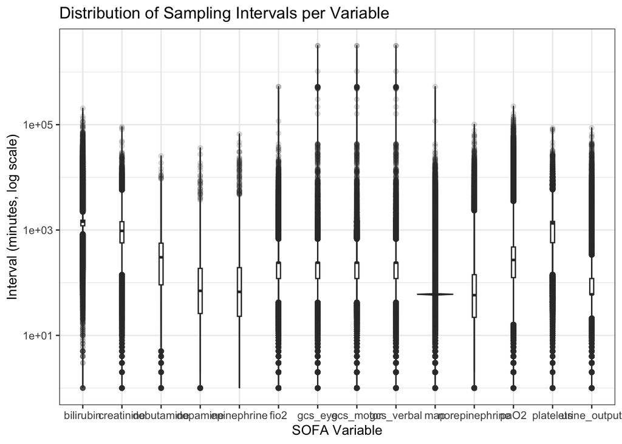

```r
# viz
# violin Plot of sampling intervals (log-scale)

ggplot(intervals, aes(x = var_name, y = diff_mins)) +
  geom_violin(fill = "skyblue", alpha = 0.6) +
  geom_boxplot(width = 0.1, outlier.alpha = 0.15) +
  scale_y_log10() +
  theme_bw() +
  labs(
    title = "Distribution of Sampling Intervals per Variable",
    x = "SOFA Variable",
    y = "Interval (minutes, log scale)"
  )
```

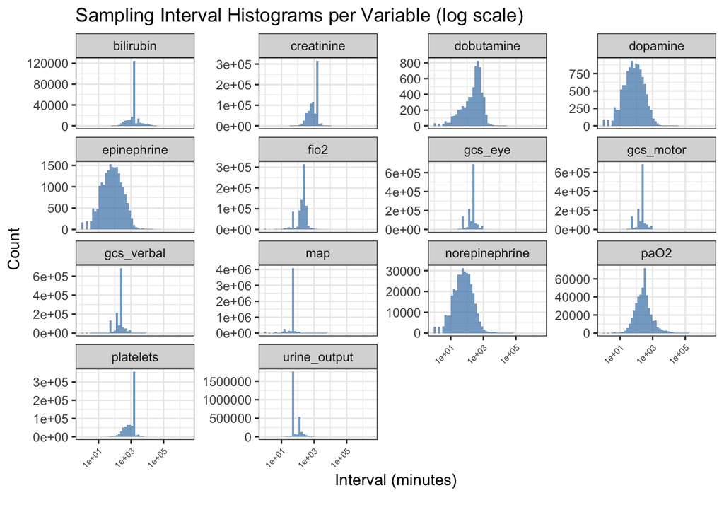

```r
ggplot(intervals, aes(x = diff_mins)) +
  geom_histogram(bins = 50, fill = "steelblue", alpha = 0.7) +
  scale_x_log10() +
  facet_wrap(~ var_name, scales = "free_y") +
  theme_bw() +
  theme(
    plot.margin = margin(5.5, 5.5, 20, 5.5),  # extra room bottom
    axis.text.x = element_text(angle = 45, hjust = 1, size = 6)
  ) +
  labs(
    title = "Sampling Interval Histograms per Variable (log scale)",
    x = "Interval (minutes)",
    y = "Count"
  )
```

For each admission, a running records of all observed variables would be maintained along with current SOFA score. Whenever a new observation arrives, SOFA score would be updated and check whether the change >= 2. If true, the updated time stamp would be considered sepsis onset. Note that our search is conducted on a subset of suspected infection patients, and according to Sepsis-3 the baseline SOFA should be 0. Hence, the goal for the search is to find (if any) the earliest SOFA score >= 2.

It is also critical to distinguish the temporal window used here from the one previously for suspected infection detection. While suspected infection was define using a [-24h, +72h] window to link cultures with antibiotics, the search for organ dysfunction utilizes a window of 48 hours before and up to 24 hours after the onset of infection. This wider window is derived from Singer et al. (2016), which accounts for the variable lag between infection onset and physiological deterioration. The SOFA scoring logic follows the standard 0-4 scale proposed by Vincent et al. (1996). To handle missing data, clinically normal defaults were used for imputation: missing FiO2 was assumed to be 21% (room air), and missing Glasgow Coma Scale was assumed to be 15 (fully alert).

```r
# 2.c) procedural search to identify SOFA change >= 2

# Window slicing: "Considers a period as great as 48 hours before and up to 24 hours after onset of infection, although sensitivity analyses have tested windows as short as 3 hours before and 3 hours after onset of infection. (Singer et al. (2016)"
sofa_window <- sofa_raw_vars %>%
  inner_join(
    suspected_infection_onset %>% select(subject_id, hadm_id, infection_time),
    by = c("subject_id", "hadm_id")
  ) %>%
  mutate(
    time_diff = as.numeric(difftime(charttime, infection_time, units = "hours"))
  ) %>%
  filter(time_diff >= -48 & time_diff <= 24)

sofa_matrix <- sofa_window %>%
  select(subject_id, hadm_id, charttime, var_name, value) %>%
  group_by(subject_id, hadm_id, charttime, var_name) %>%
  summarise(value = mean(value, na.rm = TRUE), .groups = "drop") %>%
  pivot_wider(
    names_from = var_name,
    values_from = value
  ) %>%
  arrange(subject_id, hadm_id, charttime) %>%
  group_by(subject_id, hadm_id) %>%
  mutate(across(everything(), ~ na.locf(., na.rm = FALSE))) %>%
  ungroup()
```

```r
sofa_calculated <- sofa_matrix %>%
  mutate(
    # Respiratory: PaO2/FiO2 ratio
    # Imputation Logic: MIT-LCP Standard (Johnson et al.)
    # If FiO2 missing -> assume Room Air (21%)
    fio2_filled = ifelse(is.na(fio2), 21, fio2),
    pf_ratio = if_else(!is.na(paO2), paO2 / (fio2_filled / 100), NA_real_),

    sofa_resp = case_when(
      pf_ratio < 100 ~ 4,
      pf_ratio < 200 ~ 3,
      pf_ratio < 300 ~ 2,
      pf_ratio < 400 ~ 1,
      TRUE ~ 0
    ),

    # Coagulation (Platelets)
    sofa_coag = case_when(
      platelets < 20 ~ 4,
      platelets < 50 ~ 3,
      platelets < 100 ~ 2,
      platelets < 150 ~ 1,
      TRUE ~ 0
    ),

    # Liver (Bilirubin)
    sofa_liver = case_when(
      bilirubin >= 12.0 ~ 4,
      bilirubin >= 6.0 ~ 3,
      bilirubin >= 2.0 ~ 2,
      bilirubin >= 1.2 ~ 1,
      TRUE ~ 0
    ),

    # Cardiovascular (MAP & Vasopressors)
    sofa_cardio = case_when(
      (!is.na(dopamine) & dopamine > 15) | (!is.na(norepinephrine) & norepinephrine > 0.1) | (!is.na(epinephrine) & epinephrine > 0.1) ~ 4,
      (!is.na(dopamine) & dopamine > 5) | (!is.na(norepinephrine) & norepinephrine <= 0.1) | (!is.na(epinephrine) & epinephrine <= 0.1) ~ 3,
      (!is.na(dopamine) | !is.na(dobutamine)) ~ 2,
      map < 70 ~ 1,
      TRUE ~ 0
    ),

    # CNS (GCS)
    # Imputation Logic: Assume Normal (15) if missing to avoid false positives
    gcs_score = coalesce(gcs_eye, 4) + coalesce(gcs_motor, 6) + coalesce(gcs_verbal, 5),
    sofa_cns = case_when(
      gcs_score <= 5 ~ 4,
      gcs_score <= 9 ~ 3,
      gcs_score <= 12 ~ 2,
      gcs_score <= 14 ~ 1,
      TRUE ~ 0
    ),

    # Renal (Creatinine & Urine)
    sofa_renal = case_when(
      creatinine >= 5.0 | (!is.na(urine_output) & urine_output < 200) ~ 4,
      creatinine >= 3.5 | (!is.na(urine_output) & urine_output < 500) ~ 3,
      creatinine >= 2.0 ~ 2,
      creatinine >= 1.2 ~ 1,
      TRUE ~ 0
    ),

    total_sofa = sofa_resp + sofa_coag + sofa_liver + sofa_cardio + sofa_cns + sofa_renal
  )

# find earliest time where SOFA >= 2; since baseline SOFA assumed to be 0, find earliest time stamp.
sepsis_onset <- sofa_calculated %>%
  group_by(subject_id, hadm_id) %>%
  filter(total_sofa >= 2) %>%
  arrange(charttime) %>%
  slice(1) %>%
  select(subject_id, hadm_id, sepsis_onset_time = charttime, first_sofa_score = total_sofa) %>%
  left_join(infected_icustays %>% select(subject_id, hadm_id, stay_id),
            by = c("subject_id", "hadm_id")) %>%
  ungroup() %>%
  relocate(stay_id, .after = hadm_id)

head(sepsis_onset)
```

```
# A tibble: 6 × 5
  subject_id  hadm_id  stay_id sepsis_onset_time   first_sofa_score
       <dbl>    <dbl>    <dbl> <dttm>                         <dbl>
1   10000690 25860671 37081114 2150-11-02 21:27:00                5
2   10000980 26913865 39765666 2189-06-27 09:08:00                3
3   10001725 25563031 31205490 2110-04-11 17:00:00                3
4   10001843 26133978 39698942 2134-12-05 09:08:00                3
5   10001884 26184834 37510196 2131-01-11 01:51:00                2
6   10002013 23581541 39060235 2160-05-18 14:30:00                9
```

Now, sepsis_onset identifies the sepsis_onset_time base on Sepsis-3 criteria, and each trajectory is identified by subject_id, hadm_id, and stay_id. We do a quick descriptive summary on the sepsis cohort. In this step, we also explore possible confounding variables such as demographic variables; later steps will involve a more complete set of potential confounding variables that directly linked to patient’s disease severity using comorbidities derived from icu_diagnoses.

```r
# Sepsis Prevalence
n_total_patients <- n_distinct(patients$subject_id)
n_sepsis_patients <- n_distinct(sepsis_onset$subject_id)
n_non_sepsis <- n_total_patients - n_sepsis_patients
sepsis_prevalence <- (n_sepsis_patients / n_total_patients) * 100

cat(sprintf("Total Patients in Database: %d\n", n_total_patients))
```

```
Total Patients in Database: 65366
```

```r
cat(sprintf("Patients Meeting Sepsis-3 Criteria: %d\n", n_sepsis_patients))
```

```
Patients Meeting Sepsis-3 Criteria: 34755
```

```r
cat(sprintf("Sepsis Prevalence: %.2f%%\n", sepsis_prevalence))
```

```
Sepsis Prevalence: 53.17%
```

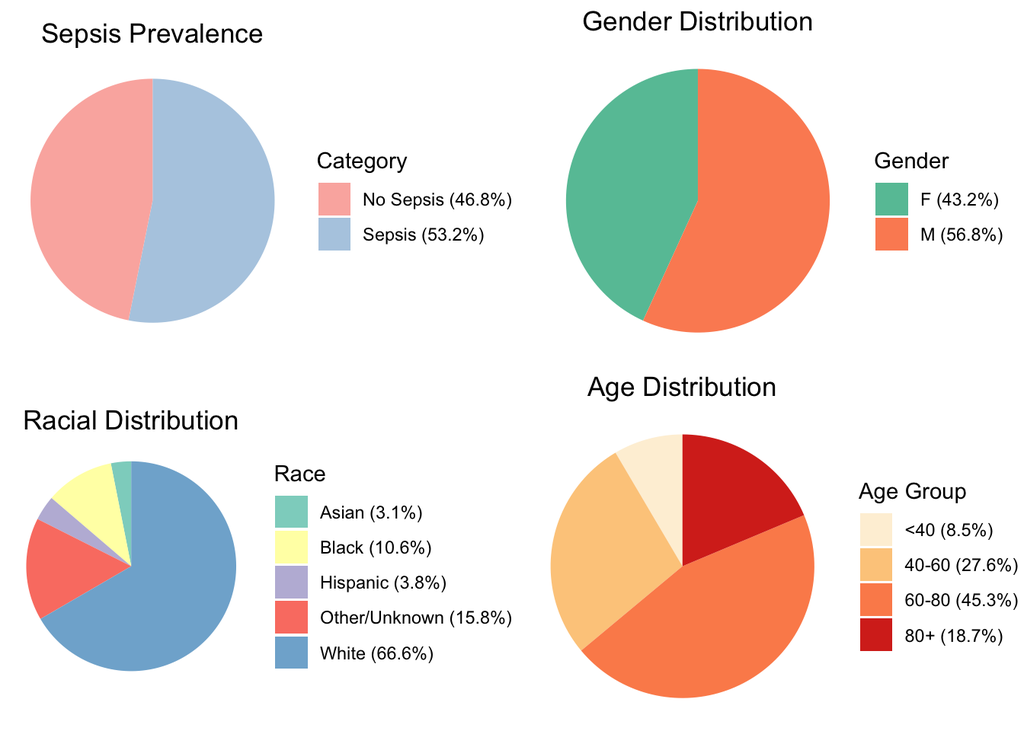

```r
# viz
prev_data <- data.frame(
  Category = c("Sepsis", "No Sepsis"),
  Count = c(n_sepsis_patients, n_non_sepsis)
) %>%
  mutate(
    Percentage = Count / sum(Count) * 100,
    Label = paste0(Category, "\n", round(Percentage, 1), "%")
  )


sepsis_demographics <- sepsis_onset %>%
  left_join(patients %>% select(subject_id, gender, anchor_age), by = "subject_id") %>%
  left_join(admissions %>% select(hadm_id, race), by = "hadm_id") %>%
  mutate(
    age_group = case_when(
      anchor_age < 40 ~ "<40",
      anchor_age >= 40 & anchor_age < 60 ~ "40-60",
      anchor_age >= 60 & anchor_age < 80 ~ "60-80",
      anchor_age >= 80 ~ "80+",
      TRUE ~ "Unknown"
    ),
    race_simple = case_when(
      str_detect(race, "WHITE") ~ "White",
      str_detect(race, "BLACK") ~ "Black",
      str_detect(race, "HISPANIC|LATINO") ~ "Hispanic",
      str_detect(race, "ASIAN") ~ "Asian",
      TRUE ~ "Other/Unknown"
    )
  )

# gender
gender_data <- sepsis_demographics %>%
  count(gender) %>%
  mutate(
    Percentage = n / sum(n) * 100,
    Label = paste0(gender, "\n", round(Percentage, 1), "%")
  )

# race
race_data <- sepsis_demographics %>%
  count(race_simple) %>%
  mutate(
    Percentage = n / sum(n) * 100,
    Label = paste0(race_simple, "\n", round(Percentage, 1), "%")
  )

# age
age_data <- sepsis_demographics %>%
  count(age_group) %>%
  mutate(
    Percentage = n / sum(n) * 100,
    Label = paste0(age_group, "\n", round(Percentage, 1), "%")
  )

# viz


# Prevalence Plot
prev_data <- prev_data %>%
  mutate(Legend_Label = paste0(Category, " (", round(Percentage, 1), "%)"))

p_prev <- ggplot(prev_data, aes(x = "", y = Count, fill = Legend_Label)) +
  geom_bar(stat = "identity", width = 1) +
  coord_polar("y", start = 0) +
  theme_void() +
  scale_fill_brewer(palette = "Pastel1") +
  labs(title = "Sepsis Prevalence", fill = "Category") + # Set legend title
  theme(legend.position = "right", plot.title = element_text(hjust = 0.5))

# Gender Plot
gender_data <- gender_data %>%
  mutate(Legend_Label = paste0(gender, " (", round(Percentage, 1), "%)"))

p_gender <- ggplot(gender_data, aes(x = "", y = n, fill = Legend_Label)) +
  geom_bar(stat = "identity", width = 1) +
  coord_polar("y", start = 0) +
  theme_void() +
  scale_fill_brewer(palette = "Set2") +
  labs(title = "Gender Distribution", fill = "Gender") +
  theme(legend.position = "right", plot.title = element_text(hjust = 0.5))

# Race Plot
race_data <- race_data %>%
  mutate(Legend_Label = paste0(race_simple, " (", round(Percentage, 1), "%)"))

p_race <- ggplot(race_data, aes(x = "", y = n, fill = Legend_Label)) +
  geom_bar(stat = "identity", width = 1) +
  coord_polar("y", start = 0) +
  theme_void() +
  scale_fill_brewer(palette = "Set3") +
  labs(title = "Racial Distribution", fill = "Race") +
  theme(legend.position = "right", plot.title = element_text(hjust = 0.5))

# Age Plot
age_order <- c("<40", "40-60", "60-80", "80+", "Unknown")
age_data <- sepsis_demographics %>%
  count(age_group) %>%
  mutate(
    Percentage = n / sum(n) * 100,
    age_group = factor(age_group, levels = age_order),
    # Create the label
    Legend_Label = paste0(age_group, " (", round(Percentage, 1), "%)")
  ) %>%
  filter(!is.na(age_group)) %>%
  arrange(age_group)

age_data$Legend_Label <- factor(age_data$Legend_Label,
                                levels = age_data$Legend_Label)

p_age <- ggplot(age_data, aes(x = "", y = n, fill = Legend_Label)) +
  geom_bar(stat = "identity", width = 1) +
  coord_polar("y", start = 0) +
  theme_void() +
  scale_fill_brewer(palette = "OrRd") +
  labs(title = "Age Distribution", fill = "Age Group") +
  theme(legend.position = "right", plot.title = element_text(hjust = 0.5))

grid.arrange(p_prev, p_gender, p_race, p_age, ncol = 2)
```

As shown in the plot, the initial cohort characterization identified a high prevalence of sepsis (53.2%) within the study sample, with a demographic distribution heavily skewed towards elderly patients (64% aged > 60) and white (66.6%). This distinct profile calls for a more comprehensive confounding analysis in later stages. Next, we will define and build “Time-to-Antibiotics” (TTA) as a continuous variable, and several metrics for “improved outcomes”.

### 3.4 Feature Engineering

#### 3.4.1 Defining Time-To-Antibiotics (TTA)

Time-To-Antibiotics was defined as the temporal difference in hours between the first systemic antibiotic administration and the confirmed sepsis onset. We identified the earliest antibiotic event within a window of -48 to +24 hours relative to onset. Note that we retained negative TTA values (antibiotics administered before the SOFA score threshold was met) to capture pre-emptive clinical care; as excluding these early recognizers would introduce immortal time bias by artificially selecting for patients with delayed progression.

```r
# extract antibiotic events using regex from prescriptions table
antibiotic_events <- prescriptions %>%
  filter(
    str_detect(
      tolower(drug),
      "penicillin|ampicillin|amoxicillin|cef|ceph|meropenem|imipenem|
       vanco|piperacillin|tazobactam|azithro|levofloxacin|cipro|
       clinda|metronidazole|linezolid|ertapenem|trimethoprim|sulfa"
    )
  ) %>%
  select(subject_id, hadm_id, antibiotic_time = starttime)

# calculate TTA: associate first antibiotic administered within [-48h, +24h] of the onset. Negative TTA values preserved to indicate pre-emptive treatment
tta_cohort <- sepsis_onset %>%
  left_join(antibiotic_events, by = c("subject_id", "hadm_id")) %>%
  mutate(
    diff_time = as.numeric(difftime(antibiotic_time, sepsis_onset_time, units = "hours"))
  ) %>%
  # scope down search by filtering time window
  filter(diff_time >= -48 & diff_time <= 24) %>%
  # leave earliest timestamp
  group_by(subject_id, hadm_id) %>%
  arrange(diff_time) %>%
  slice(1) %>%
  ungroup() %>%
  mutate(
    tta_hours = diff_time,
    # Binary Cohorts for later analysis:
    # "Early Treatment" defined as <= 1 hour after onse
    early_tx_1h = ifelse(tta_hours <= 1, 1, 0),
    early_tx_3h = ifelse(tta_hours <= 3, 1, 0)
  ) %>%
  select(subject_id, hadm_id, stay_id, sepsis_onset_time, first_abx_time = antibiotic_time, tta_hours, early_tx_1h, early_tx_3h)
```

#### 3.4.2 Defining Improved Outcomes

Patient outcomes were derived by linking the cohort to admissions, icustays, and procedureevents tables. We defined In-hospital Mortality and 28-day Mortality using discharge flags and death timestamps. ICU Length of Stay (LOS) was calculated as the duration between unit admission and discharge. Finally, we calculated Ventilator-Free Days where survivors were assigned 28 - days on ventilator, while non-survivors within 28 days were penalized heavily with a score of 0.

```r
# quickly check itemid matches invasive ventilation
check_id <- d_items %>%
  filter(itemid == 225792) %>%
  select(itemid, label, abbreviation, linksto)
check_id
```

```
# A tibble: 1 × 4
  itemid label                abbreviation         linksto
   <dbl> <chr>                <chr>                <chr>
1 225792 Invasive Ventilation Invasive Ventilation procedureevents
```

```r
# construct ventilation duration column
vent_durations <- procedureevents %>%
  filter(itemid == 225792) %>%
  mutate(
    duration_mins = as.numeric(difftime(endtime, starttime, units = "mins"))
  ) %>%
  group_by(subject_id, stay_id) %>%
  summarise(
    # convert total_vent_days_calc (in minutes) to days
    total_vent_days_calc = sum(duration_mins, na.rm = TRUE) / 1440,
    .groups = "drop"
  )

analytic_cohort <- tta_cohort %>%
  left_join(admissions %>% select(subject_id, hadm_id, hospital_expire_flag, deathtime, admittime),
            by = c("subject_id", "hadm_id")) %>%
  # join ICU LOS Data
  left_join(icustays %>% select(subject_id, hadm_id, stay_id, intime, outtime),
            by = c("subject_id", "hadm_id", "stay_id")) %>%
  # join Ventilation Data
  left_join(vent_durations %>% select(stay_id, total_vent_days_calc), by = "stay_id") %>%
  mutate(
    # 1. Mortality
    mortality_hosp = as.numeric(hospital_expire_flag),
    # 2. LOS
    los_icu_days = as.numeric(difftime(outtime, intime, units = "days")),
    # 3. 28-Day Mortality Flag
    days_to_death = as.numeric(difftime(deathtime, admittime, units = "days")),
    mortality_28d = ifelse(!is.na(days_to_death) & days_to_death <= 28, 1, 0),
    # 4. VFD-28
    # extra logic applied to penalize death:
    # if died within 28 days / days on vnet > 28 -> 0
    # if survived > 28 days > 28
    # if never ventilated > 28
    vent_days_imputed = replace_na(total_vent_days_calc, 0),
    vfd_28 = case_when(
      mortality_28d == 1 ~ 0,
      vent_days_imputed >= 28 ~ 0,
      TRUE ~ 28 - vent_days_imputed
    )
  ) %>%
  select(subject_id, hadm_id, stay_id, tta_hours, early_tx_1h, early_tx_3h,
         mortality_hosp, mortality_28d, los_icu_days, vfd_28)

# quick summary on Y variables
# continuous var
analytic_cohort %>%
  select(tta_hours, los_icu_days, vfd_28) %>%
  summary() %>%
  print()
```

```
   tta_hours         los_icu_days           vfd_28
 Min.   :-48.0000   Min.   :2.269e-03   Min.   : 0.00
 1st Qu.: -0.2667   1st Qu.:1.263e+00   1st Qu.:24.91
 Median :  1.6000   Median :2.282e+00   Median :27.93
 Mean   :  2.0149   Mean   :4.350e+00   Mean   :22.79
 3rd Qu.:  5.0000   3rd Qu.:4.755e+00   3rd Qu.:28.00
 Max.   : 24.0000   Max.   :1.597e+02   Max.   :28.00
```

```r
# categorical vars
analytic_cohort %>%
  select(early_tx_1h, mortality_hosp, mortality_28d) %>%
  mutate(across(everything(), as.factor)) %>%
  summary() %>%
  print()
```

```
 early_tx_1h mortality_hosp mortality_28d
 0:19104     0:28869        0:29267
 1:14897     1: 5132        1: 4734
```

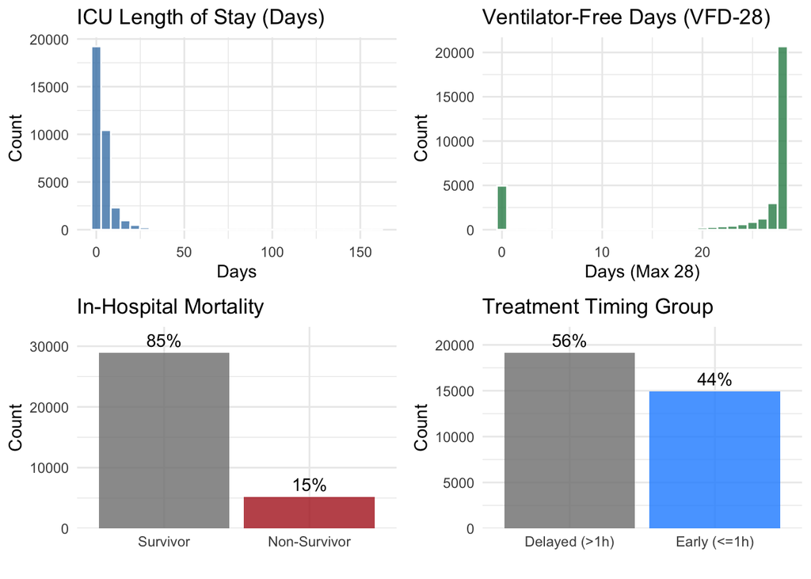

```r
# LOS
p_los <- ggplot(analytic_cohort, aes(x = los_icu_days)) +
  geom_histogram(bins = 30, fill = "steelblue", color = "white", alpha = 0.8) +
  labs(title = "ICU Length of Stay (Days)", x = "Days", y = "Count") +
  theme_minimal()

# VFD-28
p_vfd <- ggplot(analytic_cohort, aes(x = vfd_28)) +
  geom_histogram(binwidth = 1, fill = "seagreen", color = "white", alpha = 0.8) +
  labs(title = "Ventilator-Free Days (VFD-28)", x = "Days (Max 28)", y = "Count") +
  theme_minimal()

# In-hospital Mortality
p_mort <- analytic_cohort %>%
  count(mortality_hosp) %>%
  mutate(pct = n / sum(n)) %>%
  ggplot(aes(x = factor(mortality_hosp), y = n, fill = factor(mortality_hosp))) +
  geom_col(alpha = 0.8, show.legend = FALSE) +
  scale_y_continuous(expand = expansion(mult = c(0, 0.15))) +
  geom_text(aes(label = percent(pct)), vjust = -0.5) +
  scale_x_discrete(labels = c("Survivor", "Non-Survivor")) +
  scale_fill_manual(values = c("gray50", "firebrick")) +
  labs(title = "In-Hospital Mortality", x = "", y = "Count") +
  theme_minimal()

# Early treatment (< 1h)
p_early <- analytic_cohort %>%
  count(early_tx_1h) %>%
  mutate(pct = n / sum(n)) %>%
  ggplot(aes(x = factor(early_tx_1h), y = n, fill = factor(early_tx_1h))) +
  geom_col(alpha = 0.8, show.legend = FALSE) +
  scale_y_continuous(expand = expansion(mult = c(0, 0.15))) +
  geom_text(aes(label = percent(pct)), vjust = -0.5) +
  scale_x_discrete(labels = c("Delayed (>1h)", "Early (<=1h)")) +
  scale_fill_manual(values = c("gray50", "dodgerblue")) +
  labs(title = "Treatment Timing Group", x = "", y = "Count") +
  theme_minimal()

grid.arrange(p_los, p_vfd, p_mort, p_early, ncol = 2)
```

#### 3.4.3 Data Quality, Preprocessing, and Feature Engineering

As of now, the ingredients needed for Confounding analysis and later modeling is almost complete. In this section, I would construct and retrieve features needed, and conduct a data quality audit to check for outliers and impute. Finally, I would apply log0transofrmation to address the long-tail outliers problems mentioned in last section.

Firstly, we pull all data columns that we plan to audit, and fetch lactate (for Septic Shock vs. Stable Sepsis confounding analysis), and calculate Charlson Comorbidity Index.

```r
# Fetch Lactate (Crucial for Septic Shock Definition)
# itemid 50813 is Lactate
lactate_events <- labevents %>%
  semi_join(sepsis_onset, by = c("subject_id", "hadm_id")) %>%
  filter(itemid == 50813) %>%
  select(subject_id, hadm_id, charttime, lactate_val = valuenum) %>%
  filter(lactate_val < 50)

# Link Lactate to the Sepsis Onset window [-6h, +24h]
# We take the MAX lactate in this window to capture the "worst" state
lactate_merged <- sepsis_onset %>%
  left_join(lactate_events, by = c("subject_id", "hadm_id")) %>%
  mutate(
    diff_hours = as.numeric(difftime(charttime, sepsis_onset_time, units = "hours"))
  ) %>%
  filter(diff_hours >= -6 & diff_hours <= 24) %>%
  group_by(subject_id, hadm_id) %>%
  summarise(
    max_lactate = max(lactate_val, na.rm = TRUE),
    .groups = "drop"
  ) %>%
  # Handle cases where no lactate was drawn (Inf warnings from max)
  mutate(max_lactate = ifelse(is.infinite(max_lactate), NA, max_lactate))


# Calculate Charlson Comorbidity Index (CCI)
# We use a simplified mapping for the demo based on ICD codes in diagnoses_icd
# (In a full production scale, we would use the 'comorbidity' R package)

charlson_map <- diagnoses_icd %>%
  semi_join(sepsis_onset, by = c("subject_id", "hadm_id")) %>%
  mutate(
    # Simple regex for major Charlson components
    mi = as.integer(str_detect(icd_code, "^410|^412|^I21|^I22")),
    chf = as.integer(str_detect(icd_code, "^428|^I50")),
    pvd = as.integer(str_detect(icd_code, "^441|^443|^I71|^I73")),
    cvd = as.integer(str_detect(icd_code, "^430|^438|^I60|^I69")),
    dementia = as.integer(str_detect(icd_code, "^290|^F00|^F03")),
    copd = as.integer(str_detect(icd_code, "^490|^496|^J40|^J44")),
    rheum = as.integer(str_detect(icd_code, "^710|^714|^M05|^M06")),
    liver_mild = as.integer(str_detect(icd_code, "^571|^K70|^K73")),
    diabetes = as.integer(str_detect(icd_code, "^250|^E10|^E14")),
    renal = as.integer(str_detect(icd_code, "^585|^N18")),
    malignancy = as.integer(str_detect(icd_code, "^196|^199|^C77|^C80"))
  ) %>%
  group_by(subject_id, hadm_id) %>%
  summarise(
    # Simple unweighted sum for this demo (CCI usually weighted)
    charlson_index = max(mi) + max(chf) + max(pvd) + max(cvd) + max(dementia) +
                     max(copd) + max(rheum) + max(liver_mild) + max(diabetes) +
                     max(renal) + max(malignancy),
    .groups = "drop"
  )

# Join these new features back to the main analytic_cohort
analytic_cohort_ext <- analytic_cohort %>%
  left_join(lactate_merged, by = c("subject_id", "hadm_id")) %>%
  left_join(charlson_map, by = c("subject_id", "hadm_id"))
```

Then, I check for outliers and missingness in Lactate, due since it is usually recorded in low frequency.

```r
# Missingness Assessment
missing_summary <- analytic_cohort_ext %>%
  summarise(
    missing_lactate = sum(is.na(max_lactate)),
    pct_missing_lactate = mean(is.na(max_lactate)) * 100,
    missing_charlson = sum(is.na(charlson_index)),
    # Baseline SOFA is in 'sepsis_onset' table, let's pull it in for checking
    # (Checking if any patient failed to get a score)
    n_total = n()
  )

print("Missingness Summary:")
```

```
[1] "Missingness Summary:"
```

```r
print(missing_summary)
```

```
# A tibble: 1 × 4
  missing_lactate pct_missing_lactate missing_charlson n_total
            <int>               <dbl>            <int>   <int>
1            9229                27.1                8   34001
```

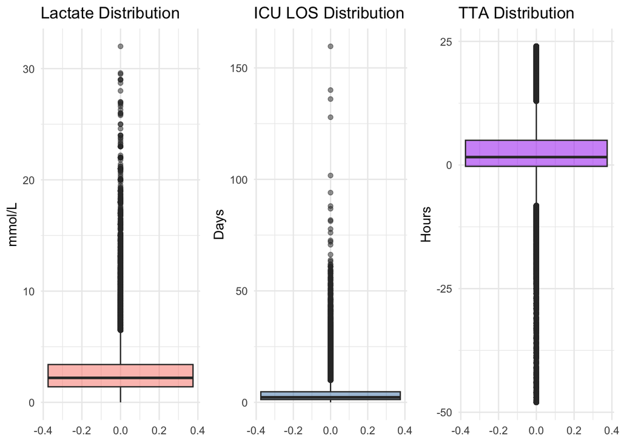

```r
# Outlier Visualization
# We check Lactate, LOS, and TTA for extreme outliers
p_outlier_lactate <- ggplot(analytic_cohort_ext, aes(y = max_lactate)) +
  geom_boxplot(fill = "salmon", alpha = 0.5) +
  labs(title = "Lactate Distribution", y = "mmol/L") + theme_minimal()

p_outlier_los <- ggplot(analytic_cohort_ext, aes(y = los_icu_days)) +
  geom_boxplot(fill = "steelblue", alpha = 0.5) +
  labs(title = "ICU LOS Distribution", y = "Days") + theme_minimal()

p_outlier_tta <- ggplot(analytic_cohort_ext, aes(y = tta_hours)) +
  geom_boxplot(fill = "purple", alpha = 0.5) +
  labs(title = "TTA Distribution", y = "Hours") + theme_minimal()

grid.arrange(p_outlier_lactate, p_outlier_los, p_outlier_tta, ncol = 3)
```

Next, the final analytic cohort is constructed. We do a quick data exploratory analysis to better understand the confounders, and construct the table 1:

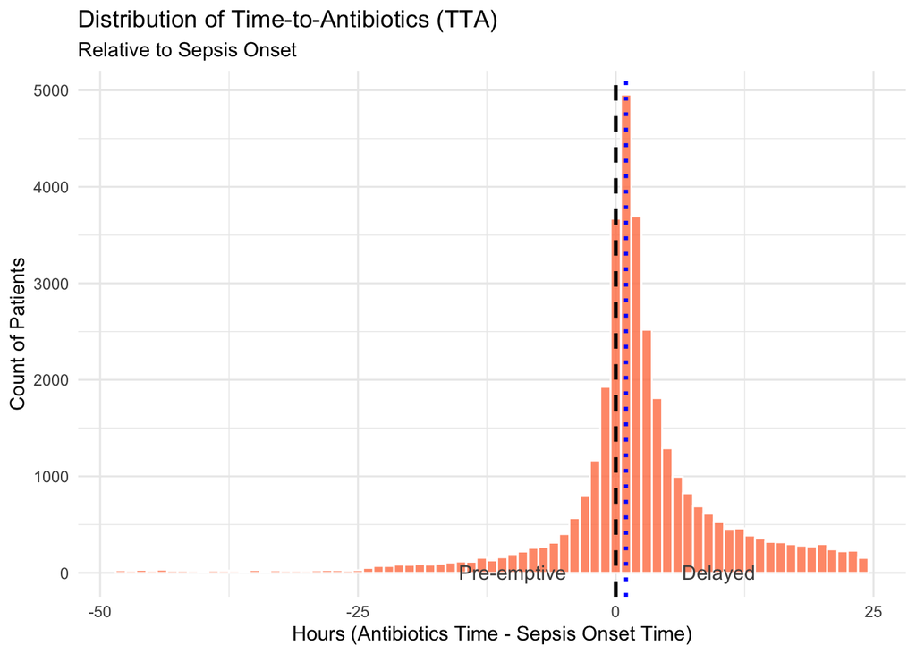

```r
# viz: distribution of TTA
ggplot(analytic_cohort, aes(x = tta_hours)) +
  geom_histogram(binwidth = 1, fill = "coral", color = "white", alpha = 0.8) +
  geom_vline(xintercept = 0, linetype = "dashed", color = "black", size = 1) +
  geom_vline(xintercept = 1, linetype = "dotted", color = "blue", size = 1) +
  annotate("text", x = -10, y = 5, label = "Pre-emptive", color = "gray30") +
  annotate("text", x = 10, y = 5, label = "Delayed", color = "gray30") +
  labs(
    title = "Distribution of Time-to-Antibiotics (TTA)",
    subtitle = "Relative to Sepsis Onset",
    x = "Hours (Antibiotics Time - Sepsis Onset Time)",
    y = "Count of Patients"
  ) +
  theme_minimal()
```

As shown in the histogram, the peak sits around 0 to +2 hours, which is expected as for most patients, clinical team quickly starts administer antibiotics as soon as there’s a sign of organ failure. There are also healthy amount of variance, where some were identified to receive pre-emptive treatment before SOFA score spiked, and some received delayed treatment up to 25h.

```r
vaso_flag <- inputevents %>%
  inner_join(sepsis_onset %>% select(subject_id, stay_id, hadm_id, sepsis_onset_time),
             by = c("subject_id", "stay_id")) %>%
  mutate(
    time_diff = as.numeric(difftime(starttime, sepsis_onset_time, units = "hours"))
  ) %>%
  filter(time_diff >= -6 & time_diff <= 24) %>%
  distinct(subject_id, hadm_id) %>%
  mutate(vaso_active = 1)

analytic_final <- analytic_cohort_ext %>%
  left_join(vaso_flag, by = c("subject_id", "hadm_id")) %>%
  left_join(patients %>% select(subject_id, anchor_age, gender), by = "subject_id") %>%
  left_join(sepsis_onset %>% select(subject_id, hadm_id, first_sofa_score),
            by = c("subject_id", "hadm_id")) %>%
  mutate(
    log_los = log(los_icu_days + 0.1),
    good_outcome_vfd = ifelse(vfd_28 > 20, 1, 0),

    vaso_active = replace_na(vaso_active, 0),
    max_lactate_imp = replace_na(max_lactate, 1.0),

    septic_shock_numeric = ifelse(vaso_active == 1 & max_lactate_imp > 2.0, 1, 0),
    charlson_index = replace_na(charlson_index, 0)
  )


analytic_final$septic_shock_factor <- factor(analytic_final$septic_shock_numeric,
                                             levels = c(0, 1), labels = c("No Shock", "Septic Shock"))
analytic_final$mortality_factor <- factor(analytic_final$mortality_hosp,
                                          levels = c(0, 1), labels = c("Survivor", "Non-Survivor"))
analytic_final$gender_factor <- factor(analytic_final$gender,
                                       levels = c("F", "M"), labels = c("Female", "Male"))
analytic_final$timing_group <- factor(analytic_final$early_tx_1h,
                                      levels = c(1, 0), labels = c("Early Tx (<=1h)", "Delayed Tx (>1h)"))

label(analytic_final$anchor_age) <- "Age"
label(analytic_final$gender_factor) <- "Gender"
label(analytic_final$charlson_index) <- "Charlson Comorbidity Index"
label(analytic_final$first_sofa_score) <- "Baseline SOFA Score"
label(analytic_final$max_lactate_imp) <- "Lactate (max in 24h)"
label(analytic_final$septic_shock_factor) <- "Septic Shock (Sepsis-3)"
label(analytic_final$mortality_factor) <- "In-Hospital Mortality"

table1(~ anchor_age + gender_factor + charlson_index + first_sofa_score +
         max_lactate_imp + septic_shock_factor + mortality_factor | timing_group,
       data = analytic_final,
       caption = "Table 1: Baseline Characteristics Stratified by Treatment Timing")
```

Table 1: Baseline Characteristics Stratified by Treatment Timing

|  | Early Tx (<=1h) (N=14897) | Delayed Tx (>1h) (N=19104) | Overall (N=34001) |
| --- | --- | --- | --- |
| Age |  |  |  |
| Mean (SD) | 63.4 (16.0) | 64.1 (16.5) | 63.8 (16.3) |
| Median [Min, Max] | 65.0 [18.0, 91.0] | 65.0 [18.0, 91.0] | 65.0 [18.0, 91.0] |
| Gender |  |  |  |
| Female | 6292 (42.2%) | 8403 (44.0%) | 14695 (43.2%) |
| Male | 8605 (57.8%) | 10701 (56.0%) | 19306 (56.8%) |
| Charlson Comorbidity Index |  |  |  |
| Mean (SD) | 1.12 (1.14) | 1.35 (1.22) | 1.25 (1.19) |
| Median [Min, Max] | 1.00 [0, 6.00] | 1.00 [0, 7.00] | 1.00 [0, 7.00] |
| Baseline SOFA Score |  |  |  |
| Mean (SD) | 3.69 (1.61) | 3.61 (1.44) | 3.65 (1.52) |
| Median [Min, Max] | 4.00 [2.00, 16.0] | 4.00 [2.00, 15.0] | 4.00 [2.00, 16.0] |
| Lactate (max in 24h) |  |  |  |
| Mean (SD) | 2.26 (2.10) | 2.59 (2.75) | 2.45 (2.49) |
| Median [Min, Max] | 1.60 [0.400, 29.6] | 1.60 [0, 32.0] | 1.60 [0, 32.0] |
| Septic Shock (Sepsis-3) |  |  |  |
| No Shock | 13186 (88.5%) | 15748 (82.4%) | 28934 (85.1%) |
| Septic Shock | 1711 (11.5%) | 3356 (17.6%) | 5067 (14.9%) |
| In-Hospital Mortality |  |  |  |
| Survivor | 13216 (88.7%) | 15653 (81.9%) | 28869 (84.9%) |
| Non-Survivor | 1681 (11.3%) | 3451 (18.1%) | 5132 (15.1%) |

### 3.5 Modeling and Results

#### 3.5.1 Primary Models

To isolate the effect of antibiotic timing on survival, we fitted a multivariable logistic regression model predicting in-hospital mortality. The model adjusted for illness severity proxied by first SOFA score and septic shock status, comorbidities for chronic conditions, and age. Given the large sample size of the cohort, we utilized the full dataset without resampling despite the observed class imbalance.

**Primary: logistic regression to predict death**

```r
model_mortality <- glm(mortality_hosp ~ tta_hours + anchor_age + first_sofa_score +
                         charlson_index + septic_shock_numeric,
                       data = analytic_final,
                       family = binomial(link = "logit"))
```

```r
# viz
y_pred <- predict(model_mortality, type = "response")
y_true <- analytic_final$mortality_hosp

# model performance
model_perf <- tibble(prob = y_pred, truth = y_true) %>%
  arrange(desc(prob)) %>%
  mutate(
    TP = cumsum(truth == 1),
    FP = cumsum(truth == 0),
    Total_Pos = sum(truth == 1),
    Total_Neg = sum(truth == 0),

    TPR = TP / Total_Pos,
    FPR = FP / Total_Neg,
    Precision = TP / (TP + FP)
  )

auc_val <- sum(diff(model_perf$FPR) * (head(model_perf$TPR, -1) + tail(model_perf$TPR, -1))) / 2
print(paste("Calculated AUROC:", round(auc_val, 3)))
```

```
[1] "Calculated AUROC: 0.682"
```

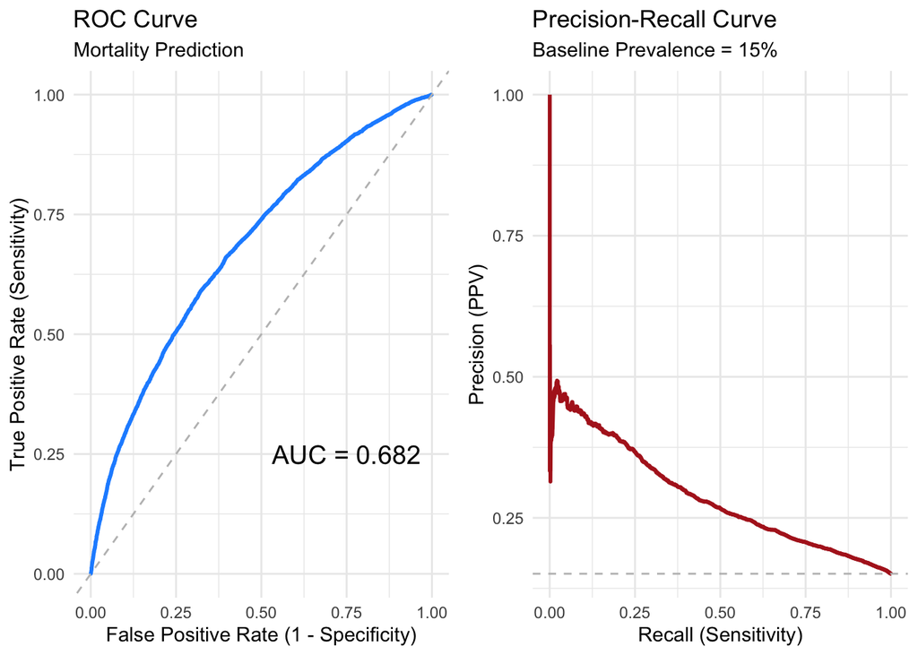

```r
# 4. Plot ROC Curve
p_roc <- ggplot(model_perf, aes(x = FPR, y = TPR)) +
  geom_line(color = "dodgerblue", size = 1) +
  geom_abline(intercept = 0, slope = 1, linetype = "dashed", color = "gray") +
  annotate("text", x = 0.75, y = 0.25, label = paste("AUC =", round(auc_val, 3)), size = 5) +
  labs(
    title = "ROC Curve",
    subtitle = "Mortality Prediction",
    x = "False Positive Rate (1 - Specificity)",
    y = "True Positive Rate (Sensitivity)"
  ) +
  theme_minimal()

baseline_prevalence <- sum(y_true == 1) / length(y_true)

p_pr <- ggplot(model_perf, aes(x = TPR, y = Precision)) +
  geom_line(color = "firebrick", size = 1) +
  geom_hline(yintercept = baseline_prevalence, linetype = "dashed", color = "gray") +
  labs(
    title = "Precision-Recall Curve",
    subtitle = paste("Baseline Prevalence =", percent(baseline_prevalence)),
    x = "Recall (Sensitivity)",
    y = "Precision (PPV)"
  ) +
  theme_minimal()

grid.arrange(p_roc, p_pr, ncol = 2)
```

```r
# viz: OR
results_table <- exp(cbind(OR = coef(model_mortality), confint(model_mortality))) %>%
  as.data.frame() %>%
  rownames_to_column(var = "Term") %>%
  rename(Lower_CI = `2.5 %`, Upper_CI = `97.5 %`) %>%
  filter(Term != "(Intercept)")
print("Adjusted Odds Ratios for In-Hospital Mortality:")
```

```
[1] "Adjusted Odds Ratios for In-Hospital Mortality:"
```

```r
print(results_table)
```

```
                  Term       OR Lower_CI Upper_CI
1            tta_hours 1.006796 1.003161 1.010478
2           anchor_age 1.015909 1.013787 1.018047
3     first_sofa_score 1.136399 1.115628 1.157455
4       charlson_index 1.181755 1.152185 1.212006
5 septic_shock_numeric 3.358872 3.132044 3.601385
```

```
`height` was translated to `width`.
```

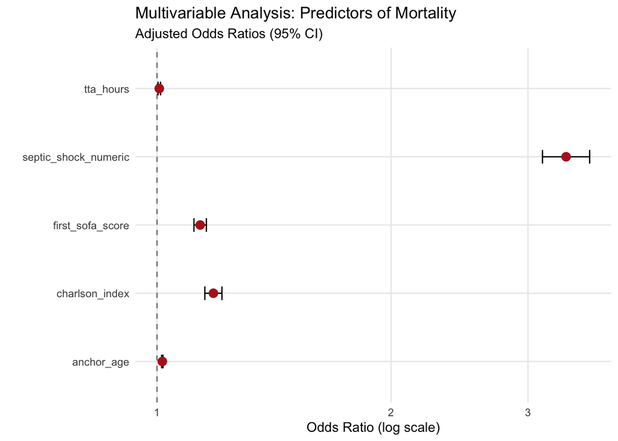

```r
ggplot(results_table, aes(x = OR, y = Term)) +
  geom_vline(xintercept = 1, linetype = "dashed", color = "gray50") +
  geom_errorbarh(aes(xmin = Lower_CI, xmax = Upper_CI), height = 0.2, color = "black") +
  geom_point(size = 3, color = "firebrick") +
  scale_x_log10() + # Log scale is standard for OR plots
  labs(
    title = "Multivariable Analysis: Predictors of Mortality",
    subtitle = "Adjusted Odds Ratios (95% CI)",
    x = "Odds Ratio (log scale)",
    y = ""
  ) +
  theme_minimal() +
  theme(panel.grid.minor = element_blank())
```

**secondary A: linear regression to predict LOS**

The primary model demonstrated moderate discriminative ability and calls for further analysis; but before that, we subsequently examine the impact of treatment delays on resource utilization, specifically ICU Length of Stay. Since LOS data is typically right-skewed as aforementioned, a log-transformation was applied.

```r
model_los <- lm(log_los ~ tta_hours + anchor_age + first_sofa_score +
                  charlson_index + septic_shock_numeric,
                data = analytic_final)

print("Model 2 Results: ICU Length of Stay (Linear Regression)")
```

```
[1] "Model 2 Results: ICU Length of Stay (Linear Regression)"
```

```r
summary(model_los)
```

```
Call:
lm(formula = log_los ~ tta_hours + anchor_age + first_sofa_score +
    charlson_index + septic_shock_numeric, data = analytic_final)

Residuals:
    Min      1Q  Median      3Q     Max
-3.3598 -0.6582 -0.1156  0.5522  3.9525

Coefficients:
                       Estimate Std. Error t value Pr(>|t|)
(Intercept)           0.9712371  0.0236606  41.049   <2e-16 ***
tta_hours             0.0004130  0.0005516   0.749    0.454
anchor_age           -0.0034404  0.0003153 -10.913   <2e-16 ***
first_sofa_score      0.0339739  0.0032606  10.420   <2e-16 ***
charlson_index        0.0502316  0.0043140  11.644   <2e-16 ***
septic_shock_numeric  0.4255007  0.0139338  30.537   <2e-16 ***
---
Signif. codes:  0 '***' 0.001 '**' 0.01 '*' 0.05 '.' 0.1 ' ' 1

Residual standard error: 0.9092 on 33995 degrees of freedom
Multiple R-squared:  0.0378,    Adjusted R-squared:  0.03766
F-statistic: 267.1 on 5 and 33995 DF,  p-value: < 2.2e-16
```

**secondary B: Logistic Regression to predict Ventilator-Free Days**

Lastly, we examine the association between TTA and VFD-28.

```r
analytic_final <- analytic_final %>%
  mutate(good_outcome_vfd = ifelse(vfd_28 > 20, 1, 0))

model_vfd <- glm(good_outcome_vfd ~ tta_hours + anchor_age + first_sofa_score +
                   charlson_index + septic_shock_numeric,
                 data = analytic_final,
                 family = binomial(link = "logit"))
```

```r
y_pred <- predict(model_vfd, type = "response")
y_true <- analytic_final$good_outcome_vfd

model_perf <- tibble(prob = y_pred, truth = y_true) %>%
  arrange(desc(prob)) %>%
  mutate(
    TP = cumsum(truth == 1),
    FP = cumsum(truth == 0),
    Total_Pos = sum(truth == 1),
    Total_Neg = sum(truth == 0),

    TPR = TP / Total_Pos,
    FPR = FP / Total_Neg,
    Precision = TP / (TP + FP)
  )

auc_val <- sum(diff(model_perf$FPR) * (head(model_perf$TPR, -1) + tail(model_perf$TPR, -1))) / 2
print(paste("Calculated AUROC (VFD Model):", round(auc_val, 3)))
```

```
[1] "Calculated AUROC (VFD Model): 0.666"
```

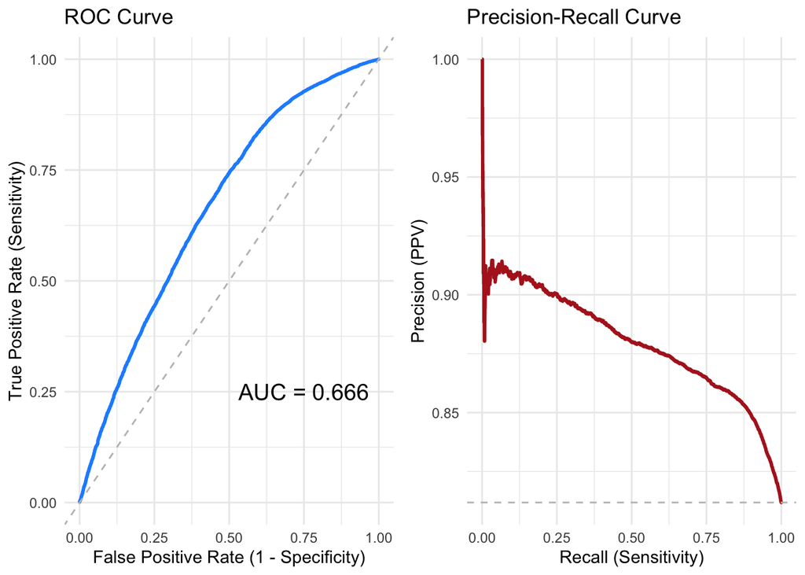

```r
p_roc <- ggplot(model_perf, aes(x = FPR, y = TPR)) +
  geom_line(color = "dodgerblue", size = 1) +
  geom_abline(intercept = 0, slope = 1, linetype = "dashed", color = "gray") +
  annotate("text", x = 0.75, y = 0.25, label = paste("AUC =", round(auc_val, 3)), size = 5) +
  labs(
    title = "ROC Curve",
    x = "False Positive Rate (1 - Specificity)",
    y = "True Positive Rate (Sensitivity)"
  ) +
  theme_minimal()

baseline_prevalence <- sum(y_true == 1) / length(y_true)

p_pr <- ggplot(model_perf, aes(x = TPR, y = Precision)) +
  geom_line(color = "firebrick", size = 1) +
  geom_hline(yintercept = baseline_prevalence, linetype = "dashed", color = "gray") +
  labs(
    title = "Precision-Recall Curve",
    x = "Recall (Sensitivity)",
    y = "Precision (PPV)"
  ) +
  theme_minimal()

grid.arrange(p_roc, p_pr, ncol = 2)
```

```r
results_table <- exp(cbind(OR = coef(model_vfd), confint(model_vfd))) %>%
  as.data.frame() %>%
  rownames_to_column(var = "Term") %>%
  rename(Lower_CI = `2.5 %`, Upper_CI = `97.5 %`) %>%
  filter(Term != "(Intercept)")
print("Adjusted Odds Ratios for Good Ventilator Outcome:")
```

```
[1] "Adjusted Odds Ratios for Good Ventilator Outcome:"
```

```r
print(results_table)
```

```
                  Term        OR  Lower_CI  Upper_CI
1            tta_hours 0.9925701 0.9892567 0.9958677
2           anchor_age 0.9929925 0.9911425 0.9948402
3     first_sofa_score 0.8798389 0.8648619 0.8951179
4       charlson_index 0.8780807 0.8575110 0.8991957
5 septic_shock_numeric 0.2677666 0.2508136 0.2858912
```

```
`height` was translated to `width`.
```

[figure not shown]

```r
ggplot(results_table, aes(x = OR, y = Term)) +
  geom_vline(xintercept = 1, linetype = "dashed", color = "gray50") +
  geom_errorbarh(aes(xmin = Lower_CI, xmax = Upper_CI), height = 0.2, color = "black") +
  geom_point(size = 3, color = "seagreen") + # Changed color to green for "Good Outcome"
  scale_x_log10() +
  labs(
    title = "Logistic Regression: Predictors of VFD-28",
    subtitle = "Ventilator-Free Days > 28 (Adjusted OR 95% CI)",
    x = "Odds Ratio (log scale)\n< 1 = Harmful | > 1 = Beneficial",
    y = ""
  ) +
  theme_minimal() +
  theme(panel.grid.minor = element_blank())
```

#### 3.5.2 Sensitivity Analysis

Sensitivity analysis is performed using a binary definition of treatment timing to capture the non-linear relationship between tta and mortality. Clinically, it is aligned to the concept of “Golden Hour” which is to say whether there is a “cliff” that distinguishes early treatment and delayed treatment in terms of improved outcom.e

```r
model_sens_binary <- glm(mortality_hosp ~ early_tx_1h + anchor_age + first_sofa_score +
                           charlson_index + septic_shock_numeric,
                         data = analytic_final,
                         family = binomial(link = "logit"))

print(exp(cbind(OR = coef(model_sens_binary), confint(model_sens_binary))))
```

```
                             OR      2.5 %     97.5 %
(Intercept)          0.02886089 0.02448619 0.03396832
early_tx_1h          0.63457799 0.59456837 0.67707736
anchor_age           1.01597344 1.01385152 1.01811019
first_sofa_score     1.14238048 1.12133540 1.16371982
charlson_index       1.16759181 1.13822364 1.19763698
septic_shock_numeric 3.24896554 3.02858449 3.48464636
```

```
`height` was translated to `width`.
```

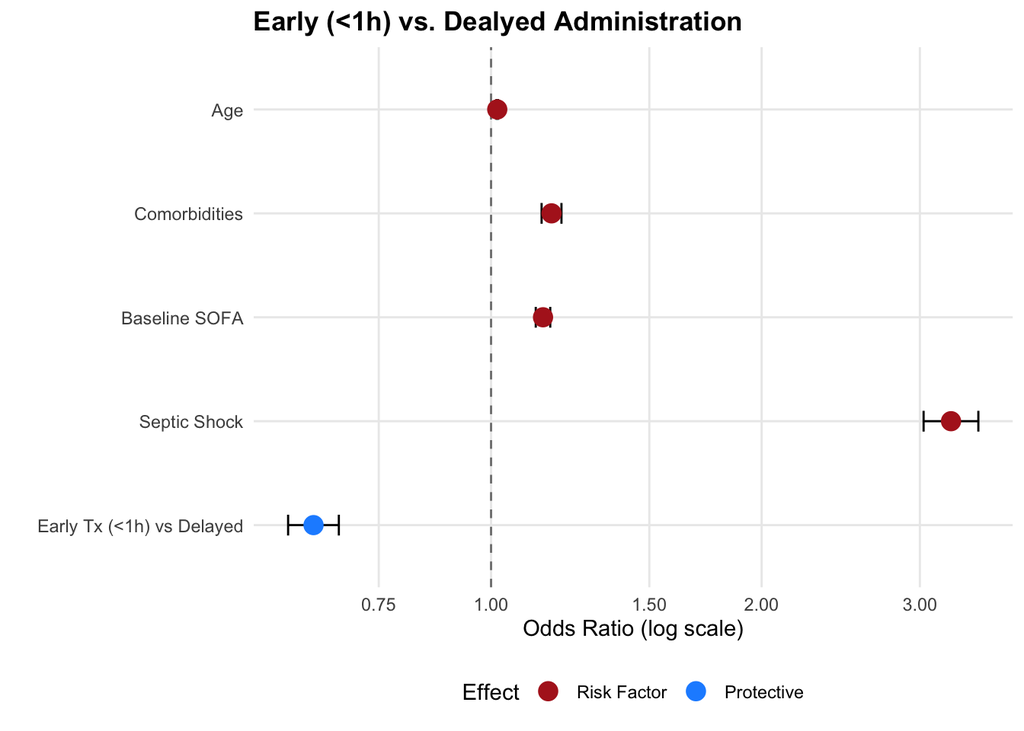

```r
results_sens <- exp(cbind(OR = coef(model_sens_binary), confint(model_sens_binary))) %>%
  as.data.frame() %>%
  rownames_to_column(var = "Term") %>%
  rename(Lower_CI = `2.5 %`, Upper_CI = `97.5 %`) %>%
  filter(Term != "(Intercept)")
results_sens$Term <- factor(results_sens$Term,
                            levels = c("early_tx_1h", "septic_shock_numeric",
                                       "first_sofa_score", "charlson_index", "anchor_age"),
                            labels = c("Early Tx (<1h) vs Delayed", "Septic Shock",
                                       "Baseline SOFA", "Comorbidities", "Age"))

ggplot(results_sens, aes(x = OR, y = Term)) +
  geom_vline(xintercept = 1, linetype = "dashed", color = "gray50") +
  geom_errorbarh(aes(xmin = Lower_CI, xmax = Upper_CI), height = 0.2, color = "black") +
  geom_point(aes(color = OR < 1), size = 4) +
  scale_color_manual(values = c("firebrick", "dodgerblue"), labels = c("Risk Factor", "Protective")) +
  scale_x_log10(breaks = c(0.5, 0.75, 1.0, 1.5, 2.0, 3.0)) +
  labs(
    title = "Early (<1h) vs. Dealyed Administration",
    x = "Odds Ratio (log scale)",
    y = "",
    color = "Effect"
  ) +
  theme_minimal() +
  theme(legend.position = "bottom",
        panel.grid.minor = element_blank(),
        plot.title = element_text(face = "bold"))
```

#### 3.5.3 Threshold Analysis

```r
cutoffs <- seq(0.5, 6.0, by = 0.5)
run_threshold_model <- function(cut_time) {
  temp_data <- analytic_final %>%
    mutate(early_tx_dynamic = ifelse(tta_hours <= cut_time, 1, 0))
  model <- glm(mortality_hosp ~ early_tx_dynamic + anchor_age + first_sofa_score +
                 charlson_index + septic_shock_numeric,
               data = temp_data,
               family = binomial(link = "logit"))
  res <- tidy(model, conf.int = TRUE, exponentiate = TRUE) %>%
    filter(term == "early_tx_dynamic") %>%
    mutate(cutoff_hour = cut_time) %>%
    select(cutoff_hour, estimate, conf.low, conf.high, p.value)

  return(res)
}


threshold_results <- map_dfr(cutoffs, run_threshold_model)

print(threshold_results)
```

```
# A tibble: 12 × 5
   cutoff_hour estimate conf.low conf.high  p.value
         <dbl>    <dbl>    <dbl>     <dbl>    <dbl>
 1         0.5    0.638    0.594     0.684 4.32e-36
 2         1      0.635    0.595     0.677 7.74e-43
 3         1.5    0.670    0.629     0.714 1.03e-35
 4         2      0.705    0.663     0.750 2.24e-28
 5         2.5    0.723    0.680     0.770 1.55e-24
 6         3      0.756    0.709     0.805 3.45e-18
 7         3.5    0.750    0.704     0.800 1.37e-18
 8         4      0.763    0.715     0.815 8.37e-16
 9         4.5    0.769    0.720     0.823 1.68e-14
10         5      0.784    0.732     0.840 4.70e-12
11         5.5    0.788    0.735     0.846 3.31e-11
12         6      0.779    0.725     0.838 1.29e-11
```

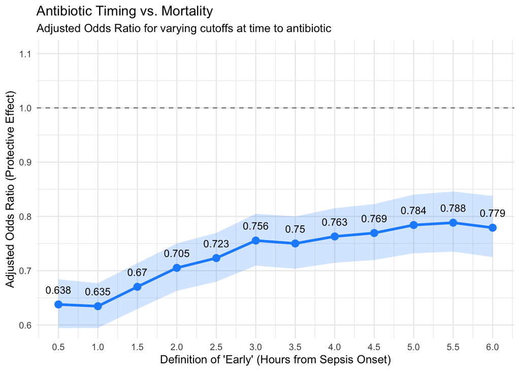

```r
ggplot(threshold_results, aes(x = cutoff_hour, y = estimate)) +
  geom_hline(yintercept = 1, linetype = "dashed", color = "gray50") +
  geom_ribbon(aes(ymin = conf.low, ymax = conf.high), fill = "dodgerblue", alpha = 0.2) +
  geom_line(color = "dodgerblue", size = 1.2) +
  geom_point(size = 3, color = "dodgerblue") +
  geom_text(aes(label = round(estimate, 3)), vjust = -1.5, size = 3.5) +
  scale_x_continuous(breaks = cutoffs) +
  coord_cartesian(ylim = c(0.6, 1.1)) +
  labs(
    title = "Antibiotic Timing vs. Mortality",
    subtitle = "Adjusted Odds Ratio for varying cutoffs at time to antibiotic",
    x = "Definition of 'Early' (Hours from Sepsis Onset)",
    y = "Adjusted Odds Ratio (Protective Effect)"
  ) +
  theme_minimal()
```

The threshold trajectory plot confirms that the protective effect of antibiotics is time-dependent and non-linear. The 1-hour cutoff represented the global optimum, yielding the strongest protective effect (lowest Odds Ratio). As the definition of “early” delays, the protective effect gradually decreases with the odds ratio trending back toward 1.0.

## 4 Conclusion

The study utilized the MIMIC-IV dataset to examine the association between the timing of antibiotic administration and clinical outcomes in sepsis patients. Our analysis reveals a non-linear relationship between intervention speed and patient outcomes.

Finally, our investigation also highlights a critical influence of confounding by indication. Descriptive analysis (Table 1) first revealed that patients in the “delayed” treatment group ironically presented with higher severity markers, including elevated lactate and a higher prevalence of septic shock. In our multivariable models, these severity metrics such as SOFA score and presence of shock remained the dominant predictors of mortality. This indicates that while rapid antibiotics are protective, the patient’s baseline physiological state remains the primary driver of survival, which could be indicative for resource allocation and triage protocols.

## 5 Reference

Singer, Mervyn, et al. “*T*he Third International Consensus Definitions for Sepsis and Septic Shock (Sepsis-3).” *JAMA*, vol. 315, no. 8, 2016, pp. 801–810, https://doi.org/10.1001/jama.2016.0287.

Shan, Wenhong, et al. “Predicting Sepsis Onset in ICU Patients Using Machine Learning and Feature Selection: A Case Study of MIMIC-IV Data.” *2024 IEEE International Conference on Medical Artificial Intelligence (MedAI)*, IEEE, 2024, doi:10.1109/MedAI62885.2024.00077.

Vincent, J. L., et al. “The SOFA (Sepsis-Related Organ Failure Assessment) Score to Describe Organ Dysfunction/Failure. On Behalf of the Working Group on Sepsis-Related Problems of the European Society of Intensive Care Medicine.” *Intensive Care Medicine*, vol. 22, no. 7, 1996, pp. 707–710, doi:10.1007/BF01709751.

Wheeler, Derek S. “Is the ‘Golden Age’ of the ‘Golden Hour’ in Sepsis Over?” *Critical Care*, vol. 19, 2015, p. 447, doi:10.1186/s13054-015-1167-3.

Forde, C., & Scullin, P. (2017). “Chasing the Golden Hour: Lessons learned from improving initial neutropenic sepsis management.” *BMJ Quality Improvement Reports*, 6(1), u204420.w6531. https://doi.org/10.1136/bmjquality.u204420.w6531

Johnson, Alistair E. W., et al. “The MIMIC Code Repository: Enabling Reproducibility in Critical Care Research.” *Journal of the American Medical Informatics Association*, vol. 25, no. 1, Jan. 2018, pp. 32–39, https://doi.org/10.1093/jamia/ocx084.